# Big Data Analysis and Prediction of Football Players' Performances, Market Values, and Team Results ⚽️🏟️

# Project Overview

This project aims to utilize Big Data techniques with PySpark to analyze and predict various aspects of football, focusing on player performance, market values, and team results. The dataset used for this project is sourced from Transfermarkt and includes data on top six European competitions:

- Bundesliga
- La Liga
- Premier League
- Serie A
- Ligue 1
- UEFA Champions League 🏆 (only for predicting club victories using Multiclass Classification & conformal prediction)

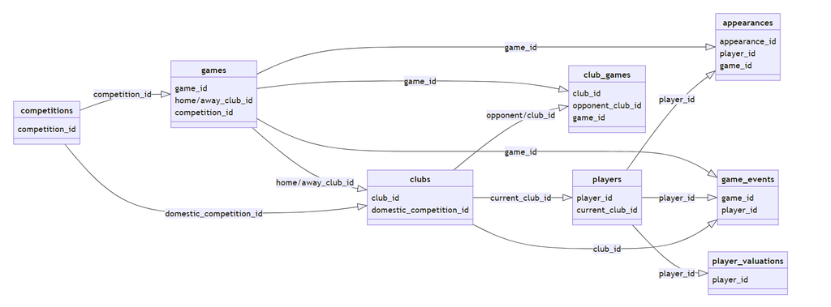

First, we import most of the libraries we'll be using throught the analysis.

## Libraries

```python
# Import SparkSession
from pyspark.sql import SparkSession
spark = SparkSession.builder \
    .appName("project") \
    .getOrCreate()
spark

# others import
import os
from pyspark.sql import functions as F
from pyspark.sql.functions import col
from pyspark.sql.functions import udf
from pyspark.sql.types import StringType
import plotly.express as px
import plotly.graph_objects as go
from pyspark.sql.functions import min, year
from pyspark.sql.window import Window
from pyspark.ml.feature import VectorAssembler
from pyspark.ml.regression import LinearRegression
from pybloom_live import BloomFilter
import time
```

[output not shown]

## Loading the Unfiltered data

```python
# loop through each file in the directory
directory_path = '/Users/alyazouzou/Documents/m2/big_data/drive-download-20241020T105551Z-001'
dataframes = {}

for file_name in os.listdir(directory_path):
    # Check if the file is a CSV file
    if file_name.endswith('.csv'):
        # Create the full file path
        file_path = os.path.join(directory_path, file_name)

        dataframes[file_name] = spark.read \
            .option("delimiter", ",") \
            .option("header", "true") \
            .option("inferSchema", "true") \
            .csv(file_path)

        print(f"{file_name} DataFrame created with {dataframes[file_name].count()} rows and {len(dataframes[file_name].columns)} columns.")
```

```
game_lineups.csv DataFrame created with 2285289 rows and 10 columns.
competitions.csv DataFrame created with 44 rows and 11 columns.
```

```
appearances.csv DataFrame created with 1604585 rows and 13 columns.
player_valuations.csv DataFrame created with 485815 rows and 5 columns.
game_events.csv DataFrame created with 759620 rows and 10 columns.
transfers.csv DataFrame created with 77490 rows and 10 columns.
players.csv DataFrame created with 32387 rows and 23 columns.
games.csv DataFrame created with 69510 rows and 23 columns.
club_games.csv DataFrame created with 139020 rows and 11 columns.
clubs.csv DataFrame created with 439 rows and 17 columns.
```

```python
df_competitions = dataframes['competitions.csv']
df_appearances = dataframes['appearances.csv']
df_games = dataframes['games.csv']
df_clubs = dataframes['clubs.csv']
df_players = dataframes['players.csv']
df_game_lineups = dataframes['game_lineups.csv']
df_club_games = dataframes['club_games.csv']
df_game_events = dataframes['game_events.csv']
df_player_valuations = dataframes['player_valuations.csv']
df_transfers = dataframes['transfers.csv']
```

## Pre-Process Data

I want only the top 6 leagues so we'll have to filter and save all the datasets.

```python
# Get unique values from the 'competition_code' column
unique_competition_codes = df_competitions.select('competition_code').distinct().collect()

print([row['competition_code'] for row in unique_competition_codes])
```

```
['ukrainian-cup', 'laliga', 'super-league-1', 'community-shield', 'toto-knvb-beker', 'europa-league', 'dfb-pokal', 'jupiler-pro-league', 'johan-cruijff-schaal', 'liga-portugal-bwin', 'ligue-1', 'russian-cup', 'allianz-cup', 'belgian-supercup', 'ukrainian-super-cup', 'europa-league-qualifikation', 'u…
```

Now we select the competitions that we want ! We'll only consider leagues & cups from France, Germany, Spain, Italy & England. (+ Champions League)

```python
# List of desired competitions
desired_competitions = [
    'ligue-1', 'trophee-des-champions', 'copa-del-rey', 'supercopa', 'serie-a', 'supercoppa-italiana',
    'premier-league', 'community-shield', 'fa-cup', 'efl-cup', 'bundesliga', 'dfl-supercup', 'dfb-pokal',
    'laliga', 'uefa-champions-league'
]

competition_mapping = {
    'ligue-1': 'FR1',
    'trophee-des-champions': 'FRCH',
    'copa-del-rey': 'CDR',
    'supercopa': 'SUC',
    'serie-a': 'IT1',
    'supercoppa-italiana': 'CIT',
    'premier-league': 'GB1',
    'community-shield': 'GBCS',
    'fa-cup': 'FAC',
    'efl-cup': 'CGB',
    'bundesliga': 'L1',
    'dfl-supercup': 'DFL',
    'dfb-pokal': 'DFB',
    'laliga': 'ES1',
    'uefa-champions-league': 'CL'
}

desired_competition_ids = list(competition_mapping.values())
```

```python
from pyspark.sql.functions import col

# 0. filter the competitions we want in games, competitions & appearances thanks to game_id
df_competitions_filtered = df_competitions.filter(col('competition_id').isin(desired_competition_ids)) # filtering competitions
print(df_competitions_filtered.count())
```

```
15
```

```python
#1. filter games based on the competition id
df_games_filtered = df_games.filter(col('competition_id').isin(desired_competition_ids))
# getting the game_id from the right list of competitions
game_ids = [row['game_id'] for row in df_games_filtered.select('game_id').distinct().collect()]

#2. filtering the appearances of players & games events, club games based on the right game_ids
df_appearances_filtered = df_appearances.filter(col('game_id').isin(game_ids))
df_game_events_filtered = df_game_events.filter(col('game_id').isin(game_ids))
df_club_games_filtered = df_club_games.filter(col('game_id').isin(game_ids))

#3. Filtering clubs table w/ the domestic_competition_id from competition filtered table
domestic_competition_ids = [row['competition_id'] for row in df_competitions_filtered.select('competition_id').distinct().collect()]
df_clubs_filtered = df_clubs.filter(col('domestic_competition_id').isin(domestic_competition_ids))

#4. filtering players table w/ the club id found in filtered clubs
club_ids = [row['club_id'] for row in df_clubs_filtered.select('club_id').distinct().collect()]
df_players_filtered = df_players.filter(col('current_club_id').isin(club_ids))

#5. filtering players valuation table w/ the player id found in filtered
player_ids = [row['player_id'] for row in df_players_filtered.select('player_id').distinct().collect()]
df_player_valuations_filtered = df_player_valuations.filter(col('player_id').isin(player_ids))

#6. filtering transfers table w/ player id
df_transfers_filtered = df_transfers.filter(col('player_id').isin(player_ids))

#7. filtering game_lineups w/ game id
df_game_lineups_filtered = df_game_lineups.filter(col('game_id').isin(game_ids))
```

```python
print(f"Filtered Competitions DataFrame has {df_competitions_filtered.count()} rows.")
print(f"Filtered Games DataFrame has {df_games_filtered.count()} rows.")
print(f"Filtered Appearances DataFrame has {df_appearances_filtered.count()} rows.")
print(f"Filtered Game Events DataFrame has {df_game_events_filtered.count()} rows.")
print(f"Filtered Club Games DataFrame has {df_club_games_filtered.count()} rows.")
print(f"Filtered Clubs DataFrame has {df_clubs_filtered.count()} rows.")
print(f"Filtered Players DataFrame has {df_players_filtered.count()} rows.")
print(f"Filtered Player Valuations DataFrame has {df_player_valuations_filtered.count()} rows.")
print(f"Filtered game_lineup DataFrame has {df_game_lineups_filtered.count()} rows.")
print(f"Filtered transfers DataFrame has {df_transfers_filtered.count()} rows.")
```

[output not shown]

## Saving Data

```python
# convert the PySpark DataFrame to a Pandas DataFrame and save
df_competitions_filtered.toPandas().to_csv('/content/drive/MyDrive/trademark_data/filtered_data/competitions_filtered.csv', index=False)
df_games_filtered.toPandas().to_csv('/content/drive/MyDrive/trademark_data/filtered_data/games_filtered.csv', index=False)
df_appearances_filtered.toPandas().to_csv('/content/drive/MyDrive/trademark_data/filtered_data/appearances_filtered.csv', index=False)
df_game_events_filtered.toPandas().to_csv('/content/drive/MyDrive/trademark_data/filtered_data/game_events_filtered.csv', index=False)
df_club_games_filtered.toPandas().to_csv('/content/drive/MyDrive/trademark_data/filtered_data/club_games_filtered.csv', index=False)
df_clubs_filtered.toPandas().to_csv('/content/drive/MyDrive/trademark_data/filtered_data/clubs_filtered.csv', index=False)
df_players_filtered.toPandas().to_csv('/content/drive/MyDrive/trademark_data/filtered_data/players_filtered.csv', index=False)
df_player_valuations_filtered.toPandas().to_csv('/content/drive/MyDrive/trademark_data/filtered_data/player_valuations_filtered.csv', index=False)

df_game_lineups_filtered.toPandas().to_csv('/content/drive/MyDrive/trademark_data/filtered_data/game_lineups_filtered.csv', index=False)
df_transfers_filtered.toPandas().to_csv('/content/drive/MyDrive/trademark_data/filtered_data/transfers_filtered.csv', index=False)
```

# Loading Pre-Processed data

```python
directory_path = '/Users/alyazouzou/Documents/m2/big_data/filtered_data'

dataframes = {}

for file_name in os.listdir(directory_path):
  file_path = os.path.join(directory_path, file_name)

  dataframes[file_name] = spark.read \
      .option("delimiter", ",") \
      .option("header", "true") \
      .option("inferSchema", "true") \
      .csv(file_path)

  # Checking
  print(f"{file_name} DataFrame created with {dataframes[file_name].count()} rows and {len(dataframes[file_name].columns)} columns.")
```

```
games_filtered.csv DataFrame created with 28463 rows and 23 columns.
appearances_filtered.csv DataFrame created with 709649 rows and 13 columns.
transfers_filtered.csv DataFrame created with 29849 rows and 10 columns.
game_lineups_filtered.csv DataFrame created with 926812 rows and 10 columns.
clubs_filtered.csv DataFrame created with 173 rows and 17 columns.
game_events_filtered.csv DataFrame created with 312454 rows and 10 columns.
competitions_filtered.csv DataFrame created with 15 rows and 11 columns.
players_filtered.csv DataFrame created with 11700 rows and 23 columns.
player_valuations_filtered.csv DataFrame created with 197116 rows and 5 columns.
club_games_filtered.csv DataFrame created with 56926 rows and 11 columns.
```

```python
df_competitions_f = dataframes['competitions_filtered.csv']
df_appearances_f = dataframes['appearances_filtered.csv']
df_games_f = dataframes['games_filtered.csv']
df_clubs_f = dataframes['clubs_filtered.csv']
df_players_f = dataframes['players_filtered.csv']
df_game_lineups_f = dataframes['game_lineups_filtered.csv']
df_club_games_f = dataframes['club_games_filtered.csv']
df_game_events_f = dataframes['game_events_filtered.csv']
df_player_valuations_f = dataframes['player_valuations_filtered.csv']
df_transfers_f = dataframes['transfers_filtered.csv']
```

# Some extra Data using User Defined Function

I’ve defined a country_data dictionary that stores flags and ISO alpha codes for different countries. I’ve also created two UDFs, get_flag_url_udf and get_iso_alpha_udf, to quickly retrieve the flag URL and ISO code for any given country. The get_country_info function helps pull this data from the dictionary when needed, allowing me to dynamically map country data during processing.

```python
country_data = {
    "France": {
        "flag_url": "https://upload.wikimedia.org/wikipedia/en/c/c3/Flag_of_France.svg",
        "iso_alpha": "FRA"
    },
    "England": {
        "flag_url": "https://upload.wikimedia.org/wikipedia/en/b/be/Flag_of_England.svg",
        "iso_alpha": "GBR"
    },
    "Germany": {
        "flag_url": "https://upload.wikimedia.org/wikipedia/en/b/ba/Flag_of_Germany.svg",
        "iso_alpha": "DEU"
    },
    "Spain": {
        "flag_url": "https://upload.wikimedia.org/wikipedia/en/9/9a/Flag_of_Spain.svg",
        "iso_alpha": "ESP"
    },
    "Italy": {
        "flag_url": "https://upload.wikimedia.org/wikipedia/en/0/03/Flag_of_Italy.svg",
        "iso_alpha": "ITA"
    },
    "Poland": {
        "flag_url": "https://upload.wikimedia.org/wikipedia/en/1/12/Flag_of_Poland.svg",
        "iso_alpha": "POL"
    },
    "Argentina": {
        "flag_url": "https://upload.wikimedia.org/wikipedia/commons/1/1a/Flag_of_Argentina.svg",
        "iso_alpha": "ARG"
    },
    "Portugal": {
        "flag_url": "https://upload.wikimedia.org/wikipedia/commons/5/5c/Flag_of_Portugal.svg",
        "iso_alpha": "PRT"
    },
    "Uruguay": {
        "flag_url": "https://upload.wikimedia.org/wikipedia/commons/f/fe/Flag_of_Uruguay.svg",
        "iso_alpha": "URY"
    },
    "Gabon": {
        "flag_url": "https://upload.wikimedia.org/wikipedia/commons/0/04/Flag_of_Gabon.svg",
        "iso_alpha": "GAB"
    },
    "Egypt": {
        "flag_url": "https://upload.wikimedia.org/wikipedia/commons/f/fe/Flag_of_Egypt.svg",
        "iso_alpha": "EGY"
    },
    "Belgium": {
        "flag_url": "https://upload.wikimedia.org/wikipedia/commons/6/65/Flag_of_Belgium.svg",
        "iso_alpha": "BEL"
    }
}

def get_country_info(country, field):
    if country in country_data:
        return country_data[country].get(field, None)
    return None

get_flag_url_udf = udf(lambda country: get_country_info(country, 'flag_url'), StringType())
get_iso_alpha_udf = udf(lambda country: get_country_info(country, 'iso_alpha'), StringType())
```

# **Player Performance Analysis:**

I did several joins to merge the necessary data from multiple DataFrames. Here’s a brief explanation of each step:

- **df_appearances_games:** I joined the appearances dataset with the games dataset on game_id to retrieve player appearances along with match details such as date, season, and game ID.
- **df_appearances_games_competitions:** Next, I joined this result with the competitions dataset to add competition details like the competition code, name, and country.
- **df_players_perf:** Then, I merged the resulting DataFrame with the clubs dataset to include information about the player's current club, and finally joined it with the players dataset to get detailed player attributes like their name, position, and market value.
- **df_clubs_total:** In another join, I combined appearances with games and clubs to calculate total team metrics such as the number of goals, assists, and additional club information like market value, average age, and squad size.
- **df_clubs_players_cost:** Finally, I joined the clubs and players datasets to compute the overall cost and player statistics per club, and I linked it with the competitions dataset to capture the country associated with each competition.

### Jointures

```python
# join appearances with games
df_appearances_games = df_appearances_f.join(
    df_games_f,
    df_appearances_f.game_id == df_games_f.game_id,
    how="inner"
).select(
    df_appearances_f.player_id,
    df_appearances_f.player_name,
    df_appearances_f.competition_id,
    df_appearances_f.player_club_id,
    df_appearances_f.goals,
    df_appearances_f.assists,
    df_appearances_f.minutes_played,
    df_games_f.date,
    df_games_f.season,
    df_games_f.game_id
)

# then with the competitions dataframe to get the name of the players current competition
df_appearances_games_competitions = df_appearances_games.join(
    df_competitions_f,
    df_appearances_games.competition_id == df_competitions_f.competition_id,
    how="inner"
).select(
    df_appearances_games["*"],
    df_competitions_f.competition_code,
    df_competitions_f.country_name,
    df_competitions_f.name.alias("competition_name")
)

# then with clubs to get the clubs of the player
df_players_perf = df_appearances_games_competitions.join(
    df_clubs_f,
    df_appearances_games_competitions.player_club_id == df_clubs_f.club_id,
    how="inner"
).select(
    df_clubs_f.name.alias("player_club"),
    df_appearances_games_competitions["*"]
)

df_players_perf = df_players_perf.join(
    df_players_f,
    df_players_perf.player_id == df_players_f.player_id,
    how="inner"
).select(
    df_players_perf["*"],
    df_players_f.country_of_birth,
    df_players_f.city_of_birth,
    df_players_f.country_of_citizenship,
    df_players_f.date_of_birth,
    df_players_f.sub_position,
    df_players_f.position,
    df_players_f.foot,
    df_players_f.height_in_cm,
    df_players_f.current_club_domestic_competition_id,
    df_players_f.current_club_name,
    df_players_f.market_value_in_eur,
    df_players_f.highest_market_value_in_eur
)

df_players_perf.show(10)
```

```
24/10/21 17:14:09 WARN package: Truncated the string representation of a plan since it was too large. This behavior can be adjusted by setting 'spark.sql.debug.maxToStringFields'.
```

```
+--------------------+---------+-----------------+--------------+--------------+-----+-------+--------------+----------+------+-------+--------------------+------------+--------------------+----------------+---------------+----------------------+-------------+------------------+----------+-----+----…
|         player_club|player_id|      player_name|competition_id|player_club_id|goals|assists|minutes_played|      date|season|game_id|    competition_code|country_name|    competition_name|country_of_birth|  city_of_birth|country_of_citizenship|date_of_birth|      sub_position|  position| foot|heig…
+--------------------+---------+-----------------+--------------+--------------+-----+-------+--------------+----------+------+-------+--------------------+------------+--------------------+----------------+---------------+----------------------+-------------+------------------+----------+-----+----…
|Montpellier Hérau...|   113707|     Rémy Cabella|          FRCH|           969|    0|      0|            65|2012-07-28|  2012|2244655|trophee-des-champ...|      France|trophee-des-champ...|          France|        Ajaccio|                France|   1990-03-08|Attacking Midfield|  Midfield|right|    …
|Montpellier Hérau...|   139955|  Emanuel Herrera|          FRCH|           969|    1|      0|            75|2012-07-28|  2012|2244655|trophee-des-champ...|      France|trophee-des-champ...|       Argentina|        Rosario|             Argentina|   1987-04-13|    Centre-Forward|    Attack|right|    …
|  Olympique Lyonnais|    17965|      Hugo Lloris|          FRCH|          1041|    0|      0|            90|2012-07-28|  2012|2244655|trophee-des-champ...|      France|trophee-des-champ...|          France|           Nice|                France|   1986-12-26|        Goalkeeper|Goalkeeper| left|    …
|  Olympique Lyonnais|    18909|     Jimmy Briand|          FRCH|          1041|    1|      0|            90|2012-07-28|  2012|2244655|trophee-des-champ...|      France|trophee-des-champ...|          France|Vitry-sur-Seine|                France|   1985-08-02|    Centre-Forward|    Attack|right|    …
|  Olympique Lyonnais|    18912|   Yoann Gourcuff|          FRCH|          1041|    0|      1|            90|2012-07-28|  2012|2244655|trophee-des-champ...|      France|trophee-des-champ...|          France|       Ploemeur|                France|   1986-07-11|Attacking Midfield|  Midfield|right|    …
|Montpellier Hérau...|    22386|    Daniel Congré|          FRCH|           969|    0|      0|            90|2012-07-28|  2012|2244655|trophee-des-champ...|      France|trophee-des-champ...|          France|       Toulouse|                France|   1985-04-05|       Centre-Back|  Defender|right|    …
|Montpellier Hérau...|    23938|Geoffrey Jourdren|          FRCH|           969|    0|      0|            90|2012-07-28|  2012|2244655|trophee-des-champ...|      France|trophee-des-champ...|          France|          Meaux|                France|   1986-02-04|        Goalkeeper|Goalkeeper|right|    …
|  Olympique Lyonnais|    33914|  Mouhamadou Dabo|          FRCH|          1041|    0|      0|            82|2012-07-28|  2012|2244655|trophee-des-champ...|      France|trophee-des-champ...|         Senegal|          Dakar|                France|   1986-11-28|        Right-Back|  Defender|right|    …
|Montpellier Hérau...|     4811|           Hilton|          FRCH|           969|    0|      0|            90|2012-07-28|  2012|2244655|trophee-des-champ...|      France|trophee-des-champ...|          Brazil|       Brasília|                Brazil|   1977-09-13|       Centre-Back|  Defender|right|    …
|Montpellier Hérau...|     5303|Souleymane Camara|          FRCH|           969|    0|      0|            25|2012-07-28|  2012|2244655|trophee-des-champ...|      France|trophee-des-champ...|         Senegal|          Dakar|               Senegal|   1982-12-22|      Right Winger|    Attack|right|    …
+--------------------+---------+-----------------+--------------+--------------+-----+-------+--------------+----------+------+-------+--------------------+------------+--------------------+----------------+---------------+----------------------+-------------+------------------+----------+-----+----…
only showing top 10 rows
```

```python
# join appearances with games
df_clubs_info = df_appearances_f.join(
    df_games_f,
    df_appearances_f.game_id == df_games_f.game_id,
    how="inner"
).select(
    df_appearances_f.competition_id,
    df_appearances_f.player_club_id,
    df_appearances_f.goals,
    df_appearances_f.assists,
    df_games_f.date,
    df_games_f.season,
    df_games_f.game_id
)

df_clubs_total = df_clubs_info.join(
    df_clubs_f,
    df_clubs_info.player_club_id == df_clubs_f.club_id,
    how="inner"
).select(
    df_clubs_info.competition_id,
    df_clubs_info.player_club_id.alias("club_id"),
    df_clubs_info.goals,
    df_clubs_info.assists,
    df_clubs_info.date,
    df_clubs_info.season,
    df_clubs_info.game_id,
    df_clubs_f.name.alias("club_name"),
    df_clubs_f.domestic_competition_id,
    df_clubs_f.total_market_value,
    df_clubs_f.squad_size,
    df_clubs_f.average_age,
    df_clubs_f.foreigners_number,
    df_clubs_f.foreigners_percentage,
    df_clubs_f.national_team_players,
    df_clubs_f.stadium_name,
    df_clubs_f.stadium_seats,
    df_clubs_f.net_transfer_record,
    df_clubs_f.coach_name,
    df_clubs_f.last_season
)

df_clubs_total = df_clubs_total.withColumn("year", F.year("date"))
df_clubs_total.show(10)
```

```
+--------------+-------+-----+-------+----------+------+-------+--------------------+-----------------------+------------------+----------+-----------+-----------------+---------------------+---------------------+------------------+-------------+-------------------+----------+-----------+----+
|competition_id|club_id|goals|assists|      date|season|game_id|           club_name|domestic_competition_id|total_market_value|squad_size|average_age|foreigners_number|foreigners_percentage|national_team_players|      stadium_name|stadium_seats|net_transfer_record|coach_name|last_season|year|
+--------------+-------+-----+-------+----------+------+-------+--------------------+-----------------------+------------------+----------+-----------+-----------------+---------------------+---------------------+------------------+-------------+-------------------+----------+-----------+----+
|          FRCH|    969|    0|      0|2012-07-28|  2012|2244655|Montpellier Hérau...|                    FR1|              null|        24|       25.5|               15|                 62.5|                    9|Stade de la Mosson|        22000|           +€12.50m|      null|       2024|2012|
|          FRCH|    969|    0|      0|2012-07-28|  2012|2244655|Montpellier Hérau...|                    FR1|              null|        24|       25.5|               15|                 62.5|                    9|Stade de la Mosson|        22000|           +€12.50m|      null|       2024|2012|
|          FRCH|    969|    1|      0|2012-07-28|  2012|2244655|Montpellier Hérau...|                    FR1|              null|        24|       25.5|               15|                 62.5|                    9|Stade de la Mosson|        22000|           +€12.50m|      null|       2024|2012|
|          FRCH|   1041|    0|      0|2012-07-28|  2012|2244655|  Olympique Lyonnais|                    FR1|              null|        31|       25.7|               21|                 67.7|                   12|  Groupama Stadium|        59186|          €-106.04m|      null|       2024|2012|
|          FRCH|   1041|    0|      0|2012-07-28|  2012|2244655|  Olympique Lyonnais|                    FR1|              null|        31|       25.7|               21|                 67.7|                   12|  Groupama Stadium|        59186|          €-106.04m|      null|       2024|2012|
|          FRCH|   1041|    1|      0|2012-07-28|  2012|2244655|  Olympique Lyonnais|                    FR1|              null|        31|       25.7|               21|                 67.7|                   12|  Groupama Stadium|        59186|          €-106.04m|      null|       2024|2012|
|          FRCH|   1041|    0|      1|2012-07-28|  2012|2244655|  Olympique Lyonnais|                    FR1|              null|        31|       25.7|               21|                 67.7|                   12|  Groupama Stadium|        59186|          €-106.04m|      null|       2024|2012|
|          FRCH|    969|    0|      0|2012-07-28|  2012|2244655|Montpellier Hérau...|                    FR1|              null|        24|       25.5|               15|                 62.5|                    9|Stade de la Mosson|        22000|           +€12.50m|      null|       2024|2012|
|          FRCH|   1041|    1|      0|2012-07-28|  2012|2244655|  Olympique Lyonnais|                    FR1|              null|        31|       25.7|               21|                 67.7|                   12|  Groupama Stadium|        59186|          €-106.04m|      null|       2024|2012|
|          FRCH|    969|    0|      0|2012-07-28|  2012|2244655|Montpellier Hérau...|                    FR1|              null|        24|       25.5|               15|                 62.5|                    9|Stade de la Mosson|        22000|           +€12.50m|      null|       2024|2012|
+--------------+-------+-----+-------+----------+------+-------+--------------------+-----------------------+------------------+----------+-----------+-----------------+---------------------+---------------------+------------------+-------------+-------------------+----------+-----------+----+
only showing top 10 rows
```

```python
from pyspark.sql import functions as F

# joining on club_id and current_club_id  to get the cost of a player and its current club
df_clubs_players_cost = df_clubs_f.join(
    df_players_f,
    df_clubs_f.club_id == df_players_f.current_club_id,
    how="inner"
).select(
    df_clubs_f.club_id,
    df_clubs_f.club_code,
    df_clubs_f.name.alias("club_name"),
    df_clubs_f.domestic_competition_id,
    #df_clubs_f.squad_size,
    #df_clubs_f.average_age,
    #df_clubs_f.foreigners_number,
    #df_clubs_f.foreigners_percentage,
    #df_clubs_f.national_team_players,
    #df_clubs_f.net_transfer_record,
    #df_clubs_f.coach_name,
    df_clubs_f.last_season.alias("club_last_season"),

    # Columns from df_players_f
    df_players_f.current_club_domestic_competition_id,
    df_players_f.player_id,
    df_players_f.first_name,
    df_players_f.last_name,
    df_players_f.name.alias("player_name"),
    df_players_f.last_season.alias("player_last_season"),
    df_players_f.current_club_id,
    #df_players_f.player_code,
    #df_players_f.country_of_birth,
    #df_players_f.city_of_birth,
    df_players_f.country_of_citizenship,
    #df_players_f.date_of_birth,
    df_players_f.sub_position,
    df_players_f.position,
    df_players_f.foot,
    df_players_f.current_club_name,
    df_players_f.market_value_in_eur,
    df_players_f.highest_market_value_in_eur
)

df_clubs_players_cost = df_clubs_players_cost.join(
    df_competitions_f,
    df_clubs_players_cost.domestic_competition_id == df_competitions_f.competition_id,
    how="inner"
).select(
    df_competitions_f.country_name ,
    df_clubs_players_cost["*"]
)

df_clubs_players_cost.show(truncate=False)
```

```
+------------+-------+------------------------+------------------------------------------------------+-----------------------+----------------+------------------------------------+---------+----------+--------------+---------------------+------------------+---------------+----------------------+----…
|country_name|club_id|club_code               |club_name                                             |domestic_competition_id|club_last_season|current_club_domestic_competition_id|player_id|first_name|last_name     |player_name          |player_last_season|current_club_id|country_of_citizenship|sub_…
+------------+-------+------------------------+------------------------------------------------------+-----------------------+----------------+------------------------------------+---------+----------+--------------+---------------------+------------------+---------------+----------------------+----…
|Italy       |398    |lazio-rom               |Società Sportiva Lazio S.p.A.                         |IT1                    |2024            |IT1                                 |10       |Miroslav  |Klose         |Miroslav Klose       |2015              |398            |Germany               |Cent…
|Germany     |16     |borussia-dortmund       |Borussia Dortmund                                     |L1                     |2024            |L1                                  |26       |Roman     |Weidenfeller  |Roman Weidenfeller   |2017              |16             |Germany               |Goal…
|Italy       |506    |juventus-turin          |Juventus Football Club                                |IT1                    |2024            |IT1                                 |77       |null      |Lúcio         |Lúcio                |2012              |506            |Brazil                |Cent…
|Germany     |27     |fc-bayern-munchen       |FC Bayern München                                     |L1                     |2024            |L1                                  |80       |Tom       |Starke        |Tom Starke           |2017              |27             |Germany               |Goal…
|Germany     |33     |fc-schalke-04           |FC Schalke 04                                         |L1                     |2022            |L1                                  |123      |Christoph |Metzelder     |Christoph Metzelder  |2012              |33             |Germany               |Cent…
|England     |11     |fc-arsenal              |Arsenal Football Club                                 |GB1                    |2024            |GB1                                 |132      |Tomas     |Rosicky       |Tomas Rosicky        |2015              |11             |Czech Republic        |Atta…
|Germany     |79     |vfb-stuttgart           |Verein für Bewegungsspiele Stuttgart 1893             |L1                     |2024            |L1                                  |162      |Marc      |Ziegler       |Marc Ziegler         |2012              |79             |Germany               |Goal…
|Spain       |1084   |fc-malaga               |Málaga CF                                             |ES1                    |2017            |ES1                                 |215      |Roque     |Santa Cruz    |Roque Santa Cruz     |2015              |1084           |Paraguay              |Cent…
|Germany     |33     |fc-schalke-04           |FC Schalke 04                                         |L1                     |2022            |L1                                  |258      |Gerald    |Asamoah       |Gerald Asamoah       |2013              |33             |Germany               |Cent…
|Germany     |79     |vfb-stuttgart           |Verein für Bewegungsspiele Stuttgart 1893             |L1                     |2024            |L1                                  |264      |Tamás     |Hajnal        |Tamás Hajnal         |2012              |79             |Hungary               |Atta…
|Spain       |3368   |ud-levante              |Levante UD                                            |ES1                    |2021            |ES1                                 |277      |Sérgio    |da Silva Pinto|Sérgio da Silva Pinto|2013              |3368           |Germany               |Cent…
|Germany     |24     |eintracht-frankfurt     |Eintracht Frankfurt Fußball AG                        |L1                     |2024            |L1                                  |332      |Benjamin  |Köhler        |Benjamin Köhler      |2012              |24             |Germany               |Left…
|Germany     |16     |borussia-dortmund       |Borussia Dortmund                                     |L1                     |2024            |L1                                  |410      |Sebastian |Kehl          |Sebastian Kehl       |2014              |16             |Germany               |Defe…
```

[output cut: 9 more lines]

## Top 10 Goal Scorers in the Last 10 Years

```python
# getting the year
df_players_perf = df_players_perf.withColumn("year", F.year("date"))
top_scorers_total = df_players_perf.groupBy("player_id", "player_name", "country_of_citizenship", "position") \
    .agg(
        F.sum("goals").alias("total_goals"),
        F.countDistinct("game_id").alias("total_games"),
        F.sum("assists").alias("total_assists"),
        F.sum("minutes_played").alias("total_minutes_played")
    ) \
    .orderBy(F.desc("total_goals")) \
    .limit(10)

top_scorers_total = top_scorers_total \
    .withColumn("flag_url", get_flag_url_udf("country_of_citizenship"))

top_scorers_total.show(truncate=False)
```

```
+---------+-------------------------+----------------------+--------+-----------+-----------+-------------+--------------------+-------------------------------------------------------------------------+
|player_id|player_name              |country_of_citizenship|position|total_goals|total_games|total_assists|total_minutes_played|flag_url                                                                 |
+---------+-------------------------+----------------------+--------+-----------+-----------+-------------+--------------------+-------------------------------------------------------------------------+
|38253    |Robert Lewandowski       |Poland                |Attack  |467        |565        |113          |47595               |https://upload.wikimedia.org/wikipedia/en/1/12/Flag_of_Poland.svg        |
|28003    |Lionel Messi             |Argentina             |Attack  |448        |520        |223          |44170               |https://upload.wikimedia.org/wikipedia/commons/1/1a/Flag_of_Argentina.svg|
|8198     |Cristiano Ronaldo        |Portugal              |Attack  |420        |465        |110          |39690               |https://upload.wikimedia.org/wikipedia/commons/5/5c/Flag_of_Portugal.svg |
|132098   |Harry Kane               |England               |Attack  |294        |422        |69           |35081               |https://upload.wikimedia.org/wikipedia/en/b/be/Flag_of_England.svg       |
|44352    |Luis Suárez              |Uruguay               |Attack  |279        |434        |146          |35055               |https://upload.wikimedia.org/wikipedia/commons/f/fe/Flag_of_Uruguay.svg  |
|58864    |Pierre-Emerick Aubameyang|Gabon                 |Attack  |255        |442        |71           |34115               |https://upload.wikimedia.org/wikipedia/commons/0/04/Flag_of_Gabon.svg    |
|18922    |Karim Benzema            |France                |Attack  |251        |455        |118          |34292               |https://upload.wikimedia.org/wikipedia/en/c/c3/Flag_of_France.svg        |
|148455   |Mohamed Salah            |Egypt                 |Attack  |249        |444        |114          |35073               |https://upload.wikimedia.org/wikipedia/commons/f/fe/Flag_of_Egypt.svg    |
|342229   |Kylian Mbappé            |France                |Attack  |241        |326        |100          |24665               |https://upload.wikimedia.org/wikipedia/en/c/c3/Flag_of_France.svg        |
|96341    |Romelu Lukaku            |Belgium               |Attack  |231        |477        |72           |36062               |https://upload.wikimedia.org/wikipedia/commons/6/65/Flag_of_Belgium.svg  |
+---------+-------------------------+----------------------+--------+-----------+-----------+-------------+--------------------+-------------------------------------------------------------------------+
```

## KNN VS KNN+LSH of Player based on their performances

We'll apply a logarithmic transformation to our data to avoid issues related to the large differences in scale between the variables. This transformation helps stabilize variance, making the data more suitable for clustering !

```python
from pyspark.sql import functions as F


cluster_player_perf = df_players_perf.groupBy("player_id", "player_name", "country_of_citizenship", "position") \
    .agg(
        F.sum("goals").alias("total_goals"),
        F.countDistinct("game_id").alias("total_games"),
        F.sum("assists").alias("total_assists"),
        F.avg('market_value_in_eur').alias("avg_market_value"),
        F.avg('minutes_played').alias("avg_minutes_played_per_game")
    ) \
    .withColumn("log_total_goals", F.log1p("total_goals")) \
    .withColumn("log_total_games", F.log1p("total_games")) \
    .withColumn("log_total_assists", F.log1p("total_assists")) \
    .withColumn("log_avg_market_value", F.log1p("avg_market_value")) \
    .withColumn("log_avg_minutes_played", F.log1p("avg_minutes_played_per_game")) \
    .select("player_id", "player_name", "country_of_citizenship", "position",
            "log_total_goals", "log_total_games", "log_total_assists",
            "log_avg_market_value", "log_avg_minutes_played") \
    .orderBy(F.desc("log_total_goals"))

cluster_player_perf = cluster_player_perf.dropna(subset=["log_total_goals", "log_total_games", "log_total_assists", "log_avg_market_value", "log_avg_minutes_played"])

# Show the result
cluster_player_perf.show()
```

```
[Stage 115:=======>                                                 (1 + 7) / 8]
```

```
+---------+--------------------+----------------------+--------+------------------+------------------+------------------+--------------------+----------------------+
|player_id|         player_name|country_of_citizenship|position|   log_total_goals|   log_total_games| log_total_assists|log_avg_market_value|log_avg_minutes_played|
+---------+--------------------+----------------------+--------+------------------+------------------+------------------+--------------------+----------------------+
|    38253|  Robert Lewandowski|                Poland|  Attack| 6.148468295917647| 6.338594078203183| 4.736198448394496|   16.52356082573315|     4.445458348836262|
|    28003|        Lionel Messi|             Argentina|  Attack|6.1070228877422545| 6.255750041753367|5.4116460518550396|  17.370858648025116|     4.453676230352024|
|     8198|   Cristiano Ronaldo|              Portugal|  Attack| 6.042632833682381| 6.144185634125646| 4.709530201312334|   16.52356082573315|     4.458464839035206|
|   132098|          Harry Kane|               England|  Attack|  5.68697535633982|6.0473721790462776| 4.248495242049359|  18.420680753952364|    4.4323671648992296|
|    44352|         Luis Suárez|               Uruguay|  Attack| 5.634789603169249| 6.075346031088684| 4.990432586778736|  15.201805169084134|     4.403933534191906|
|    58864|Pierre-Emerick Au...|                 Gabon|  Attack| 5.545177444479562| 6.093569770045136| 4.276666119016055|  15.424948670398354|     4.359055531516918|
|    18922|       Karim Benzema|                France|  Attack| 5.529429087511423|6.1224928095143865|  4.77912349311153|   16.52356082573315|     4.335551097380006|
|   148455|       Mohamed Salah|                 Egypt|  Attack| 5.521460917862246|  6.09807428216624|  4.74493212836325|  17.822843761378564|    4.3819421716475215|
|   342229|       Kylian Mbappé|                France|  Attack| 5.488937726156687|5.7899601708972535|  4.61512051684126|   19.00846741441004|     4.339373657668074|
|    96341|       Romelu Lukaku|               Belgium|  Attack|  5.44673737166631| 6.169610732491456| 4.290459441148391|  17.216707972959764|     4.338618971400419|
|    48280|      Edinson Cavani|               Uruguay|  Attack| 5.389071729816501| 5.926926025970411| 3.784189633918261|  14.731801689838349|      4.29144789101013|
|   146854|   Wissam Ben Yedder|                France|  Attack| 5.389071729816501| 6.066108090103747|  4.23410650459726|  15.894952224644102|     4.289853969579091|
|    26399|       Sergio Agüero|             Argentina|  Attack| 5.384495062789089| 5.777652323222656| 4.060443010546419|   16.52356082573315|      4.27709735797224|
|   125781|   Antoine Griezmann|                France|  Attack|  5.37989735354046| 6.246106765481563| 4.634728988229636|  17.034386422832473|     4.373397275613367|
|    68290|              Neymar|                Brazil|  Attack|5.3612921657094255| 5.834810737062605| 4.955827057601261|   17.72753358339242|    4.4298737485298005|
|    93720| Alexandre Lacazette|                France|  Attack| 5.288267030694535| 6.018593214496234| 4.248495242049359|  16.012735246411598|     4.328291336630779|
|    91845|       Heung-min Son|          Korea, South|  Attack|5.2574953720277815| 6.198478716492308| 4.553876891600541|  17.622173069956816|     4.312724579520277|
|     3455|  Zlatan Ibrahimović|                Sweden|  Attack|  5.25227342804663|  5.58724865840025| 4.304065093204169|  14.508658238524095|     4.356805216877145|
|   418560|      Erling Haaland|                Norway|  Attack| 5.198497031265826| 5.247024072160486|3.6375861597263857|   19.00846741441004|     4.404328988042952|
|    58358|       Thomas Müller|               Germany|  Attack| 5.159055299214529| 6.214608098422191|5.2832037287379885|  15.894952224644102|     4.278167996645046|
+---------+--------------------+----------------------+--------+------------------+------------------+------------------+--------------------+----------------------+
only showing top 20 rows
```

```python
from pyspark.ml.feature import VectorAssembler

assembler = VectorAssembler(
    inputCols=["log_total_goals", "log_total_games", "log_total_assists", "log_avg_market_value", "log_avg_minutes_played"],
    outputCol="features"
)
vector_df = assembler.transform(cluster_player_perf)
```

avec un knn simple

```python
from pyspark.sql import functions as F
from pyspark.sql.types import FloatType
from pyspark.sql.window import Window
import time

start_time = time.time()

#joueur de référence (exemple Ronaldo, player_id=8198)
player_of_interest = vector_df.filter(F.col("player_id") == 8198).select("features").first()['features']

distance_udf = F.udf(lambda features: float(features.squared_distance(player_of_interest)), FloatType())

knn_classic_df = vector_df.withColumn("distance", distance_udf(F.col("features")))

window = Window.partitionBy("distance").orderBy("distance")
knn_classic = knn_classic_df.withColumn("rank", F.row_number().over(window)).filter(F.col("rank") <= 5)

end_time = time.time()
print(f"Temps d'exécution pour KNN Classique : {end_time - start_time} secondes")

knn_classic.select("player_id", "player_name", "features", "distance").show(truncate=False)
```

```
Temps d'exécution pour KNN Classique : 0.8085198402404785 secondes
+---------+-------------------------+----------------------------------------------------------------------------------------------+-----------+
|player_id|player_name              |features                                                                                      |distance   |
+---------+-------------------------+----------------------------------------------------------------------------------------------+-----------+
|8198     |Cristiano Ronaldo        |[6.042632833682381,6.144185634125646,4.709530201312334,16.52356082573315,4.458464839035206]   |0.0        |
|38253    |Robert Lewandowski       |[6.148468295917647,6.338594078203183,4.736198448394496,16.52356082573315,4.445458348836262]   |0.049876153|
|18922    |Karim Benzema            |[5.529429087511423,6.1224928095143865,4.77912349311153,16.52356082573315,4.335551097380006]   |0.28379968 |
|125781   |Antoine Griezmann        |[5.37989735354046,6.246106765481563,4.634728988229636,17.034386422832473,4.373397275613367]   |0.72338074 |
|26399    |Sergio Agüero            |[5.384495062789089,5.777652323222656,4.060443010546419,16.52356082573315,4.27709735797224]    |1.0217004  |
|96341    |Romelu Lukaku            |[5.44673737166631,6.169610732491456,4.290459441148391,17.216707972959764,4.338618971400419]   |1.0261742  |
|93720    |Alexandre Lacazette      |[5.288267030694535,6.018593214496234,4.248495242049359,16.012735246411598,4.328291336630779]  |1.0752823  |
|146854   |Wissam Ben Yedder        |[5.389071729816501,6.066108090103747,4.23410650459726,15.894952224644102,4.289853969579091]   |1.0828443  |
|131789   |Roberto Firmino          |[4.969813299576001,6.0844994130751715,4.6443908991413725,16.52356082573315,4.302613960603164] |1.1830368  |
|28003    |Lionel Messi             |[6.1070228877422545,6.255750041753367,5.4116460518550396,17.370858648025116,4.453676230352024]|1.2274959  |
|128223   |Álvaro Morata            |[5.135798437050262,6.194405391104672,4.23410650459726,16.588099342704055,4.036139046771794]   |1.2334226  |
|170527   |Timo Werner              |[4.990432586778736,6.0014148779611505,4.382026634673881,16.648723960844016,4.227829427709662] |1.303626   |
|206050   |Paulo Dybala             |[5.043425116919247,6.016157159698354,4.31748811353631,16.811242881518265,4.222702653418242]   |1.3068491  |
|58358    |Thomas Müller            |[5.159055299214529,6.214608098422191,5.2832037287379885,15.894952224644102,4.278167996645046] |1.5424256  |
|134425   |Raheem Sterling          |[5.099866427824199,6.22455842927536,4.804021044733257,17.370858648025116,4.3030993760842104]  |1.6462488  |
|58864    |Pierre-Emerick Aubameyang|[5.545177444479562,6.093569770045136,4.276666119016055,15.424948670398354,4.359055531516918]  |1.6542261  |
|200512   |Sadio Mané               |[5.0238805208462765,5.905361848054571,4.127134385045092,17.034386422832473,4.345932177227831] |1.7076844  |
|177843   |Domenico Berardi         |[4.844187086458591,5.793013608384144,4.477336814478207,16.118095750958314,4.389111568892519]  |1.7827196  |
|171424   |Riyad Mahrez             |[4.7535901911063645,5.926926025970411,4.48863636973214,16.705882371415992,4.258604399702237]  |1.8308121  |
|91845    |Heung-min Son            |[5.2574953720277815,6.198478716492308,4.553876891600541,17.622173069956816,4.312724579520277] |1.8718057  |
+---------+-------------------------+----------------------------------------------------------------------------------------------+-----------+
only showing top 20 rows
```

avec lsh

```python
from pyspark.ml.feature import BucketedRandomProjectionLSH
from pyspark.sql import functions as F


start_time = time.time()

# LSH pour la similarité cosinus et KNN
lsh = BucketedRandomProjectionLSH(
    inputCol="features",
    outputCol="hashes",
    bucketLength=2.0,
    numHashTables=3
)
lsh_model = lsh.fit(vector_df)
player_of_interest = vector_df.filter(F.col("player_id") == 8198).select("features") # choix d'un joueur de référence ronaldo
nearest_neighbors = lsh_model.approxNearestNeighbors(vector_df, player_of_interest.first()['features'], numNearestNeighbors=5) # Recherche des voisins les plus proches (KNN avec LSH)


end_time = time.time()
print(f"Temps d'exécution pour LSH + KNN : {end_time - start_time} secondes")

nearest_neighbors.select("player_id", "player_name", "features", "distCol").show(truncate=False)
```

```
Temps d'exécution pour LSH + KNN : 0.7089381217956543 secondes
+---------+------------------+-------------------------------------------------------------------------------------------+------------------+
|player_id|player_name       |features                                                                                   |distCol           |
+---------+------------------+-------------------------------------------------------------------------------------------+------------------+
|8198     |Cristiano Ronaldo |[6.042632833682381,6.144185634125646,4.709530201312334,16.52356082573315,4.458464839035206]|0.0               |
|38253    |Robert Lewandowski|[6.148468295917647,6.338594078203183,4.736198448394496,16.52356082573315,4.445458348836262]|0.2233296943644797|
|18922    |Karim Benzema     |[5.529429087511423,6.1224928095143865,4.77912349311153,16.52356082573315,4.335551097380006]|0.5327285217394024|
|125781   |Antoine Griezmann |[5.37989735354046,6.246106765481563,4.634728988229636,17.034386422832473,4.373397275613367]|0.8505179222878642|
|26399    |Sergio Agüero     |[5.384495062789089,5.777652323222656,4.060443010546419,16.52356082573315,4.27709735797224] |1.0107919359993982|
+---------+------------------+-------------------------------------------------------------------------------------------+------------------+
```

### 1. **Temps d'exécution** :

**Interprétation** : Bien que LSH soit généralement plus rapide, dans ce cas, la différence de temps entre les deux approches est très faible, probablement en raison de la taille des données. Cependant, sur des ensembles de données beaucoup plus grands, LSH devrait montrer un gain de temps plus significatif, car il est conçu pour accélérer la recherche de similarités dans des bases de données massives. ==> trade off

### 2. **Résultats des voisins les plus proches** :

#### **KNN Classique :**

Les 5 joueurs les plus proches de Cristiano Ronaldo selon la distance euclidienne sont :

1. **Cristiano Ronaldo** (distance = 0.0)
2. **Robert Lewandowski** (distance = 0.0499)
3. **Karim Benzema** (distance = 0.2838)
4. **Antoine Griezmann** (distance = 0.7234)
5. **Sergio Agüero** (distance = 1.0217)

#### **KNN avec LSH :**

1. **Cristiano Ronaldo** (distance = 0.0)
2. **Robert Lewandowski** (distance = 0.2233)
3. **Karim Benzema** (distance = 0.5327)
4. **Antoine Griezmann** (distance = 0.8505)
5. **Sergio Agüero** (distance = 1.0108)

**Interprétation des résultats** : Les deux méthodes ont trouvé les **mêmes joueurs** comme voisins les plus proches de Cristiano Ronaldo, ce qui montre que **LSH** a bien fonctionné en approximant la similarité tout en étant plus rapide. Les distances dans le cas du KNN classique sont légèrement différentes de celles obtenues avec LSH, mais l'ordre des voisins est identique. Cela signifie que pour ce type de données, LSH parvient à donner des résultats très proches de ceux d'une recherche KNN classique, tout en optimisant la vitesse.

## Market Value and Performance

We will experiment with two methods: one utilizing Spark optimizations and the other without, both applied to a Decision Tree classifier with cross-validation, to compare their performance.

```python
import time
from pyspark.ml.feature import StringIndexer, VectorAssembler, MinMaxScaler
from pyspark.ml.classification import DecisionTreeClassifier
from pyspark.ml.evaluation import MulticlassClassificationEvaluator
from pyspark.ml.tuning import CrossValidator, ParamGridBuilder
from pyspark.ml import Pipeline
from pyspark.sql import functions as F

start_time = time.time()

decision_tree_player_perf = df_players_perf.groupBy("player_id", "player_name", "country_of_citizenship", "position") \
    .agg(
        F.sum("goals").alias("total_goals"),
        F.countDistinct("game_id").alias("total_games"),
        F.sum("assists").alias("total_assists"),
        F.avg('market_value_in_eur').alias("avg_market_value"),
        F.avg('minutes_played').alias("avg_minutes_played_per_game")
    )

decision_tree_player_perf = decision_tree_player_perf.dropna(subset=["total_goals", "total_games", "total_assists", "avg_market_value", "avg_minutes_played_per_game"])

print(f"Data aggregation completed in {time.time() - start_time:.2f} seconds")

# construction des features
indexer = StringIndexer(inputCol="position", outputCol="label")
assembler = VectorAssembler(
    inputCols=["total_goals", "total_games", "total_assists", "avg_market_value", "avg_minutes_played_per_game"],
    outputCol="features"
)
# normalisation
scaler = MinMaxScaler(inputCol="features", outputCol="scaled_features")

# creation du classifier
dt_classifier = DecisionTreeClassifier(labelCol="label", featuresCol="scaled_features")

# la pipeline
pipeline = Pipeline(stages=[indexer, assembler, scaler, dt_classifier])

# grille de paramètres
paramGrid = ParamGridBuilder() \
    .addGrid(dt_classifier.maxDepth, [3, 5]) \
    .addGrid(dt_classifier.minInstancesPerNode, [1, 3]) \
    .build()

# cross validation
crossval = CrossValidator(estimator=pipeline,
                          estimatorParamMaps=paramGrid,
                          evaluator=MulticlassClassificationEvaluator(labelCol="label", predictionCol="prediction", metricName="accuracy"),
                          numFolds=5)


train_data, test_data = decision_tree_player_perf.randomSplit([0.8, 0.2], seed=42)

start_time = time.time()
cvModel = crossval.fit(train_data)
print(f"Model training with cross-validation completed in {time.time() - start_time:.2f} seconds")

start_time = time.time()
predictions = cvModel.transform(test_data)
print(f"Prediction on test data completed in {time.time() - start_time:.2f} seconds")

start_time = time.time()
evaluator = MulticlassClassificationEvaluator(labelCol="label", predictionCol="prediction", metricName="accuracy")
accuracy = evaluator.evaluate(predictions)
print(f"Evaluation completed in {time.time() - start_time:.2f} seconds")

print(f"Test Accuracy: {accuracy:.2f}")
```

```
Data aggregation completed in 0.14 seconds
Model training with cross-validation completed in 735.65 seconds
Prediction on test data completed in 0.33 seconds
Evaluation completed in 6.24 seconds
Test Accuracy: 0.58
```

```python
!pip install findspark
```

```
Downloading findspark-2.0.1-py2.py3-none-any.whl (4.4 kB)
```

```python
import findspark
findspark.init()

from pyspark.sql import SparkSession
from pyspark.sql import functions as F
from pyspark.ml import Pipeline
from pyspark.ml.feature import StringIndexer, VectorAssembler, MinMaxScaler
from pyspark.ml.classification import DecisionTreeClassifier
from pyspark.ml.evaluation import MulticlassClassificationEvaluator
from pyspark.ml.tuning import CrossValidator, ParamGridBuilder
import time

# Initialiser la session Spark
spark = SparkSession.builder.appName("Football Players Decision Tree Optimized").getOrCreate()

start_time = time.time()
decision_tree_player_perf_opti = df_players_perf.groupBy("player_id", "player_name", "country_of_citizenship", "position") \
    .agg(
        F.sum("goals").alias("total_goals"),
        F.countDistinct("game_id").alias("total_games"),
        F.sum("assists").alias("total_assists"),
        F.avg('market_value_in_eur').alias("avg_market_value"),
        F.avg('minutes_played').alias("avg_minutes_played_per_game")
    )
decision_tree_player_perf_opti = decision_tree_player_perf_opti.dropna(subset=["total_goals", "total_games", "total_assists", "avg_market_value", "avg_minutes_played_per_game"])

print(f"Data aggregation completed in {time.time() - start_time:.2f} seconds")

# construction des features
label_indexer_opti = StringIndexer(inputCol="position", outputCol="label_indexed")
assembler_opti = VectorAssembler(
    inputCols=["total_goals", "total_games", "total_assists", "avg_market_value", "avg_minutes_played_per_game"],
    outputCol="features"
)
scaler_opti = MinMaxScaler(inputCol="features", outputCol="scaled_features")

# le classifier
dt_classifier_op = DecisionTreeClassifier(labelCol="label_indexed", featuresCol="scaled_features")

# la pipeline
pipeline_op = Pipeline(stages=[label_indexer_opti, assembler_opti, scaler_opti, dt_classifier_op])

# grille de paramètres et validation croisée
paramGrid_op = ParamGridBuilder() \
    .addGrid(dt_classifier_op.maxDepth, [3, 5]) \
    .addGrid(dt_classifier_op.minInstancesPerNode, [1, 3]) \
    .build()

crossval_op = CrossValidator(estimator=pipeline_op,
                          estimatorParamMaps=paramGrid_op,
                          evaluator=MulticlassClassificationEvaluator(labelCol="label_indexed", predictionCol="prediction", metricName="accuracy"),
                          numFolds=5)

# split
train_data_op, test_data_op = decision_tree_player_perf_opti.randomSplit([0.8, 0.2], seed=42)

# Partitionner les données pour une meilleure parallélisation
train_data_op = train_data_op.repartition(100)
test_data_op = test_data_op.repartition(100)

# Réglage du parallélisme des tâches
spark.conf.set("spark.default.parallelism", "100")

start_time = time.time()
cvModel_op = crossval_op.fit(train_data_op)
print(f"Model training with cross-validation completed in {time.time() - start_time:.2f} seconds")

best_model_op = cvModel_op.bestModel

start_time = time.time()
predictions_op = best_model_op.transform(test_data_op)
print(f"Prediction on test data completed in {time.time() - start_time:.2f} seconds")

start_time = time.time()
evaluator_op = MulticlassClassificationEvaluator(labelCol="label_indexed", predictionCol="prediction", metricName="accuracy")
accuracy = evaluator_op.evaluate(predictions_op)
print(f"Evaluation completed in {time.time() - start_time:.2f} seconds")
print(f"Test Accuracy after optimization: {accuracy:.2f}")
```

```
Data aggregation completed in 0.04 seconds
Model training with cross-validation completed in 348.67 seconds
Prediction on test data completed in 0.10 seconds
Evaluation completed in 5.41 seconds
Test Accuracy after optimization: 0.58
```

La principale optimisation que j'ai apportée concerne **l'utilisation explicite des partitions** dans le second code.

Les **partitions** permettent à Spark de diviser les données en segments plus petits, ce qui facilite leur traitement en parallèle sur plusieurs nœuds du cluster. Grâce à cette répartition, chaque partition peut être traitée indépendamment, augmentant ainsi le parallélisme et réduisant les temps d'exécution. Dans le second code, j'ai ajouté `repartition(100)` pour forcer la division des données en **100 partitions**, optimisant ainsi la parallélisation, contrairement au premier code qui utilise la partition par défaut.

### Différences de performance en termes de temps

- **Temps d'entraînement** :
  - **Sans partition explicite** : 735.65 secondes
  - **Avec partition optimisée** : 348.67 secondes
  - **Résultat** : Le temps d'entraînement est réduit de plus de 50 %.
- **Temps de prédiction** :
  - **Sans partition explicite** : 0.33 secondes
  - **Avec partition optimisée** : 0.10 secondes

# **Analysis Football Transfer Marker**

## Clubs with most goals in the Last 10 Years

```python
top_clubs_total = df_clubs_total.groupBy("club_id", "club_name", "competition_id") \
    .agg(
        F.countDistinct("game_id").alias("total_matches"), # some game ID's are duplicated
        F.sum("goals").alias("total_goals"),
        F.sum("assists").alias("total_assists"),
    ) \
    .orderBy(F.desc("total_goals"))

top_clubs_total.show()
```

```
+-------+--------------------+--------------+-------------+-----------+-------------+
|club_id|           club_name|competition_id|total_matches|total_goals|total_assists|
+-------+--------------------+--------------+-------------+-----------+-------------+
|    131|Futbol Club Barce...|           ES1|          459|       1093|          878|
|    281|Manchester City F...|           GB1|          458|       1053|          851|
|     27|   FC Bayern München|            L1|          409|       1049|          931|
|    418|Real Madrid Club ...|           ES1|          459|       1026|          869|
|    583|Paris Saint-Germa...|           FR1|          443|       1025|          802|
|     31|Liverpool Footbal...|           GB1|          458|        917|          729|
|     16|   Borussia Dortmund|            L1|          409|        890|          798|
|   6195|Società Sportiva ...|           IT1|          458|        880|          660|
|    506|Juventus Football...|           IT1|          458|        824|          625|
|     11|Arsenal Football ...|           GB1|          458|        820|          674|
|     46|Football Club Int...|           IT1|          458|        815|          681|
|     12|Associazione Spor...|           IT1|          457|        792|          609|
|    631|Chelsea Football ...|           GB1|          458|        791|          639|
|    148|Tottenham Hotspur...|           GB1|          458|        785|          627|
|   1041|  Olympique Lyonnais|           FR1|          443|        765|          571|
|    398|Società Sportiva ...|           IT1|          458|        752|          561|
|     15|Bayer 04 Leverkus...|            L1|          409|        747|          676|
|    985|Manchester United...|           GB1|          458|        741|          602|
|    800|Atalanta Bergamas...|           IT1|          458|        733|          573|
|      5|Associazione Calc...|           IT1|          458|        720|          539|
+-------+--------------------+--------------+-------------+-----------+-------------+
only showing top 20 rows
```

## Most expensives teams in the last 10 years

```python
# AVERAGE ANNUAL COST PER CLUB PER YEAR and THEIR CURRENT TEAM ....
clubs_cost_per_year = df_clubs_players_cost.groupBy(
    "club_id",
    "club_name",
    "player_last_season"
).agg(
    F.sum("market_value_in_eur").alias("total_market_value_in_eur"),  # Total market value for the club in that season
    F.collect_list("player_name").alias("squad_players")  # List of player names in the squad
)

clubs_cost_per_year_ordered = clubs_cost_per_year.orderBy(
    "club_id",
    "player_last_season"
)

clubs_cost_per_year_ordered.show(truncate=False)
```

```
+-------+-------------------------+------------------+-------------------------+----------------------------------------------------------------------------------------------------------------------------------------------------------------------------------------------------------------------------…
|club_id|club_name                |player_last_season|total_market_value_in_eur|squad_players                                                                                                                                                                                                               …
+-------+-------------------------+------------------+-------------------------+----------------------------------------------------------------------------------------------------------------------------------------------------------------------------------------------------------------------------…
|3      |1.FC Köln                |2014              |2350000.0                |[Patrick Helmes, Thomas Bröker, Miso Brecko, Daniel Halfar, Slawomir Peszko, Adam Matuszczyk, Lucas Cueto]                                                                                                                  …
|3      |1.FC Köln                |2015              |825000.0                 |[Dusan Svento, Philipp Hosiner, Kazuki Nagasawa]                                                                                                                                                                            …
|3      |1.FC Köln                |2016              |225000.0                 |[Sven Bacher, Hikmet Ciftci]                                                                                                                                                                                                …
|3      |1.FC Köln                |2017              |3150000.0                |[Dominic Maroh, Artjoms Rudnevs, Sven Müller, Filip Kusic, Birk Risa, Matthias Lehmann]                                                                                                                                     …
|3      |1.FC Köln                |2019              |1025000.0                |[Thomas Kessler, Marcel Risse, Lasse Sobiech, Brady Scott]                                                                                                                                                                  …
|3      |1.FC Köln                |2020              |5250000.0                |[Ron-Robert Zieler, Christian Clemens, Marco Höger, Frederik Sörensen, Julian Krahl, Robert Voloder, Jens Castrop]                                                                                                          …
|3      |1.FC Köln                |2021              |4300000.0                |[Rafael Czichos, Louis Schaub, Niklas Hauptmann, Tomás Ostrák, Marvin Obuz]                                                                                                                                                 …
|3      |1.FC Köln                |2022              |1.055E7                  |[Anthony Modeste, Jonas Hector, Sebastian Andersson, Julian Roloff, Georg Strauch, Tim Lemperle, Maximilian Schmid, Joshua Schwirten, Jonas Urbig, Nikola Soldo, Rijad Smajic]                                              …
|3      |1.FC Köln                |2023              |6.655E7                  |[Philipp Pentke, Florian Kainz, Leart Paçarada, Dominique Heintz, Mark Uth, Sargis Adamyan, Marvin Schwäbe, Benno Schmitz, Davie Selke, Luca Waldschmidt, Matthias Köbbing, Timo Hübers, Florian Dietz, Dejan Ljubicic, Stef…
|4      |1.FC Nuremberg           |2012              |700000.0                 |[Marcos António, Roussel Ngankam, Mu Kanazaki, Noah Korczowski, Max Nawe]                                                                                                                                                   …
|4      |1.FC Nuremberg           |2013              |1600000.0                |[Javier Pinola, Alexander Stephan, Timo Gebhart, Patrick Rakovsky, Sebastian Gärtner, Markus Mendler, Manuel Bihr, Sinan Tekerci, Hanno Balitsch, Emanuel Pogatetz, Raphael Schäfer]                                        …
|4      |1.FC Nuremberg           |2018              |1.0E7                    |[Ivo Ilicevic, Enrico Valentini, Georg Margreitter, Hanno Behrens, Christian Mathenia, Lukas Jäger, Sebastian Kerk, Federico Palacios, Ewerton, Mikael Ishak, Ondrej Petrak, Edgar Salli, Tim Leibold, Dennis Lippert, Adam …
|5      |Associazione Calcio Milan|2012              |450000.0                 |[Philipp Prosenik, Simone Ganz, Davide Narduzzo]                                                                                                                                                                            …
```

[output cut: 9 more lines]

```python
# .... MOST EXPENSIVES CLUBS
# calculate total market value and list of players per club per season
clubs_cost_per_year = df_clubs_players_cost.groupBy(
    "club_id",
    "club_name",
    "player_last_season",
    "domestic_competition_id",
    "country_name"
).agg(
    F.sum("market_value_in_eur").alias("total_market_value_in_eur"),
    F.collect_list("player_name").alias("squad_players")
)

# then the average market value per club over all seasons based on the total market values
average_market_value_per_club = clubs_cost_per_year.groupBy(
    "club_id",
    "club_name",
    "domestic_competition_id",
    "country_name"
).agg(
    F.avg("total_market_value_in_eur").alias("average_market_value_in_eur")  # Average market value per club
)

# finally order by average market value in descending order
average_market_value_per_club_ordered = average_market_value_per_club.orderBy(
    F.desc("average_market_value_in_eur")
)

average_market_value_per_club_ordered.show(truncate=False)
```

```
+-------+--------------------------------------+-----------------------+------------+---------------------------+
|club_id|club_name                             |domestic_competition_id|country_name|average_market_value_in_eur|
+-------+--------------------------------------+-----------------------+------------+---------------------------+
|418    |Real Madrid Club de Fútbol            |ES1                    |Spain       |1.74078125E8               |
|677    |Ipswich Town Football Club            |GB1                    |England     |1.6275E8                   |
|703    |Nottingham Forest Football Club       |GB1                    |England     |1.4065E8                   |
|281    |Manchester City Football Club         |GB1                    |England     |1.339875E8                 |
|1148   |Brentford Football Club               |GB1                    |England     |1.1750625E8                |
|1047   |Calcio Como                           |IT1                    |Italy       |1.07675E8                  |
|583    |Paris Saint-Germain Football Club     |FR1                    |France      |9.954545454545455E7        |
|11     |Arsenal Football Club                 |GB1                    |England     |9.67326923076923E7         |
|1031   |Luton Town                            |GB1                    |England     |9.67E7                     |
|131    |Futbol Club Barcelona                 |ES1                    |Spain       |8.945681818181819E7        |
|31     |Liverpool Football Club               |GB1                    |England     |8.767291666666667E7        |
|631    |Chelsea Football Club                 |GB1                    |England     |8.70826923076923E7         |
|1237   |Brighton and Hove Albion Football Club|GB1                    |England     |8.0171875E7                |
|27     |FC Bayern München                     |L1                     |Germany     |7.793653846153846E7        |
|985    |Manchester United Football Club       |GB1                    |England     |7.225384615384616E7        |
|405    |Aston Villa Football Club             |GB1                    |England     |7.1605E7                   |
|931    |Fulham Football Club                  |GB1                    |England     |6.6716666666666664E7       |
|148    |Tottenham Hotspur Football Club       |GB1                    |England     |6.455E7                    |
|762    |Newcastle United Football Club        |GB1                    |England     |6.242272727272727E7        |
|23826  |RasenBallsport Leipzig                |L1                     |Germany     |6.0452777777777776E7       |
+-------+--------------------------------------+-----------------------+------------+---------------------------+
only showing top 20 rows
```

## We link the results and Visualize !

```python
# UDF function to format the market value
def format_market_value(market_value):
    if market_value is not None:
        return f"{int(market_value):,}".replace(",", " ") + " euros"
    return "0 euros"

format_market_value_udf = F.udf(format_market_value, StringType())
```

```python
average_market_value_per_club_ordered = average_market_value_per_club_ordered \
    .withColumnRenamed("club_name", "club_name_market") \
    .withColumnRenamed("domestic_competition_id", "domestic_competition_market") \
    .withColumnRenamed("country_name", "country_market")

# joining our results
joined_df = top_clubs_total.join(
    average_market_value_per_club_ordered,
    on='club_id',
    how='inner'
)

# droping duplicated columns
joined_df = joined_df.drop(
    "club_name_market",
    "domestic_competition_market",
    "country_market"
)

# we only select 5 top clubs
top_5_clubs = joined_df.orderBy(F.desc("total_goals")).limit(5)

# formatting the market value
top_5_clubs = top_5_clubs.withColumn(
    'formatted_market_value',
    format_market_value_udf(F.col('average_market_value_in_eur'))
)

# checking
top_5_clubs.show()

# convert to pandas for viz
top_5_clubs_pandas = top_5_clubs.toPandas()

# bubble chart
fig = px.scatter(
    top_5_clubs_pandas,
    x='club_name',
    y='total_goals',
    size='average_market_value_in_eur',
    color='total_matches',
    hover_name='club_name',
    hover_data={
        'formatted_market_value': True,
        'total_goals': True,
        'total_matches': True
    },
    title="Top 5 Most Expensive Clubs by Total Goals and Market Value",
    labels={'total_goals': 'Total Goals', 'club_name': 'Club Name', 'average_market_value_in_eur': 'Average Market Value'},
    height=600,
    size_max=100,
    color_continuous_scale=px.colors.sequential.Blues
)

fig.show()
```

```
+-------+--------------------+--------------+-------------+-----------+-------------+---------------------------+----------------------+
|club_id|           club_name|competition_id|total_matches|total_goals|total_assists|average_market_value_in_eur|formatted_market_value|
+-------+--------------------+--------------+-------------+-----------+-------------+---------------------------+----------------------+
|    131|Futbol Club Barce...|           ES1|          459|       1093|          878|        8.945681818181819E7|      89 456 818 euros|
|    281|Manchester City F...|           GB1|          458|       1053|          851|                 1.339875E8|     133 987 500 euros|
|     27|   FC Bayern München|            L1|          409|       1049|          931|        7.793653846153846E7|      77 936 538 euros|
|    418|Real Madrid Club ...|           ES1|          459|       1026|          869|               1.74078125E8|     174 078 125 euros|
|    583|Paris Saint-Germa...|           FR1|          443|       1025|          802|        9.954545454545455E7|      99 545 454 euros|
+-------+--------------------+--------------+-------------+-----------+-------------+---------------------------+----------------------+
```

[interactive chart not shown]

## Does the goal average of a player impact his market value ?

The most expensives Players in the last 10 years and their goal average

```python
df_player_totals = df_players_perf.groupBy(
    "player_id", "player_name", "position"
).agg(
    F.sum("goals").alias("total_goals"),
    F.countDistinct("game_id").alias("total_matches"),
    F.avg("market_value_in_eur").alias("average_market_value_in_eur")
)

# the goal average
df_player_totals = df_player_totals.withColumn(
    "goal_average", F.col("total_goals") / F.col("total_matches")
)

df_player_totals = df_player_totals.withColumn("log_total_goals", F.log1p("total_goals")) \
                                   .withColumn("log_total_matches", F.log1p("total_matches")) \
                                   .withColumn("log_avg_market_value", F.log1p("average_market_value_in_eur"))

df_player_totals.select(
    "player_id",
    "player_name",
    "position",
    "log_total_goals",
    "log_total_matches",
    "log_avg_market_value",
    "goal_average"
).show(10, truncate=False)
```

```
+---------+----------------+----------+------------------+-----------------+--------------------+--------------------+
|player_id|player_name     |position  |log_total_goals   |log_total_matches|log_avg_market_value|goal_average        |
+---------+----------------+----------+------------------+-----------------+--------------------+--------------------+
|203496   |Nabil Fekir     |Midfield  |4.394449154672439 |5.726847747587197|16.118095750958314  |0.26143790849673204 |
|88683    |Mattia Destro   |Attack    |4.418840607796598 |5.697093486505405|13.122365377402328  |0.2760942760942761  |
|12907    |Alessio Cragno  |Goalkeeper|0.0               |5.204006687076795|14.220976332738882  |0.0                 |
|29241    |Thiago Silva    |Defender  |3.091042453358316 |6.040254711277414|13.815511557963774  |0.050119331742243436|
|182906   |Mike Maignan    |Goalkeeper|0.0               |5.568344503761097|17.453096744006448  |0.0                 |
|274839   |Wilfred Ndidi   |Midfield  |2.3978952727983707|5.389071729816501|16.588099342704055  |0.045871559633027525|
|53239    |Jonathan Pereira|Attack    |1.791759469228055 |3.828641396489095|12.206077645517674  |0.1111111111111111  |
|62121    |Odion Ighalo    |Attack    |3.4965075614664802|4.836281906951478|14.403297778421795  |0.256               |
|37418    |Éder            |Attack    |4.02535169073515  |5.272999558563747|12.206077645517674  |0.28350515463917525 |
|206050   |Paulo Dybala    |Attack    |5.043425116919247 |6.016157159698354|16.811242881518265  |0.3765281173594132  |
+---------+----------------+----------+------------------+-----------------+--------------------+--------------------+
only showing top 10 rows
```

Now, we want to explore the relationship between a player's market value and their goal average. We expect a positive correlation, where a higher market value typically indicates a higher goal-scoring ability at least.

```python
from pyspark.ml.feature import VectorAssembler
from pyspark.ml.regression import LinearRegression

# drop nulls
df_regression = df_player_totals.dropna(subset=["log_avg_market_value", "goal_average"])
df_regression = df_regression.filter(F.col("position") == "Attack")

assembler = VectorAssembler(
    inputCols=["log_avg_market_value"],
    outputCol="features"
)

df_regression = assembler.transform(df_regression)

# we train
lr = LinearRegression(featuresCol="features", labelCol="goal_average")
lr_model = lr.fit(df_regression)

# results
print(f"Coefficients: {lr_model.coefficients}")
print(f"Intercept: {lr_model.intercept}")

# evaluation
training_summary = lr_model.summary
print(f"R-squared: {training_summary.r2}")
print(f"Root Mean Squared Error (RMSE): {training_summary.rootMeanSquaredError}")
print(f"Mean Absolute Error (MAE): {training_summary.meanAbsoluteError}")

# showing predictions
predictions = lr_model.transform(df_regression)
predictions.select("player_id", "player_name", "log_avg_market_value", "goal_average", "prediction").show(10, truncate=False)
```

```
Coefficients: [0.02804072093665263]
Intercept: -0.2613825564254611
R-squared: 0.12565054452458846
Root Mean Squared Error (RMSE): 0.132602187517532
Mean Absolute Error (MAE): 0.09577124177644777
+---------+-----------------+--------------------+-------------------+--------------------+
|player_id|player_name      |log_avg_market_value|goal_average       |prediction          |
+---------+-----------------+--------------------+-------------------+--------------------+
|88683    |Mattia Destro    |13.122365377402328  |0.2760942760942761 |0.10657802915106995 |
|53239    |Jonathan Pereira |12.206077645517674  |0.1111111111111111 |0.08088466056361393 |
|62121    |Odion Ighalo     |14.403297778421795  |0.256              |0.1424962971467732  |
|37418    |Éder             |12.206077645517674  |0.28350515463917525|0.08088466056361393 |
|206050   |Paulo Dybala     |16.811242881518265  |0.3765281173594132 |0.21001681381348059 |
|211722   |Abel Khaled      |10.12667110305036   |0.0                |0.022576601992438272|
|167721   |Chimy Ávila      |14.914123179965662  |0.23636363636363636|0.15682020967881832 |
|3195     |Jermaine Pennant |13.122365377402328  |0.1111111111111111 |0.10657802915106995 |
|67369    |Nick Blackman    |12.611541086966115  |0.13333333333333333|0.09225414777528451 |
|457673   |Gabriel Strefezza|15.607270193858982  |0.13829787234042554|0.17625655166347498 |
+---------+-----------------+--------------------+-------------------+--------------------+
only showing top 10 rows
```

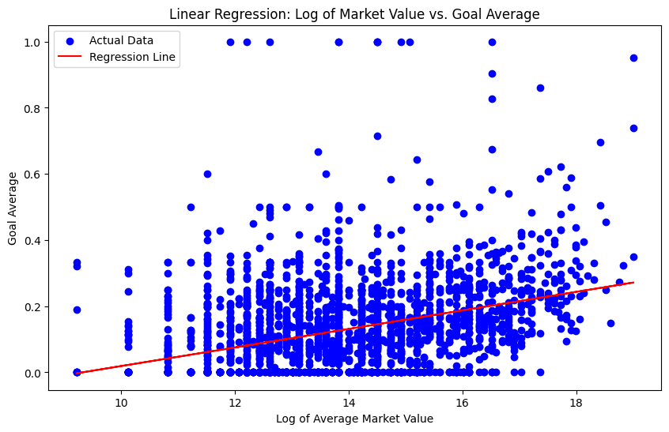

```python
#plot
import matplotlib.pyplot as plt
import pandas as pd

predictions_df = predictions.select("log_avg_market_value", "goal_average", "prediction").toPandas()

plt.figure(figsize=(10, 6))
plt.scatter(predictions_df['log_avg_market_value'], predictions_df['goal_average'], color='blue', label='Actual Data')

plt.plot(predictions_df['log_avg_market_value'], predictions_df['prediction'], color='red', label='Regression Line')

plt.xlabel("Log of Average Market Value")
plt.ylabel("Goal Average")
plt.title("Linear Regression: Log of Market Value vs. Goal Average")
plt.legend()

plt.show()
```

## Analyzing the Goal Average Evolution Over the Last 10 Years: A Comparison of Bloom Filters and Exact Methods

### BLOOM FILTER

```python
from pybloom_live import BloomFilter
from pyspark.sql import functions as F

# initializing bloom filter for game ids
bloom_filter_game_id = BloomFilter(capacity=100000, error_rate=0.001)

# udf function to check if the id in already in the filter
def is_game_duplicate(game_id):
    if game_id in bloom_filter_game_id:
        return True
    else:
        bloom_filter_game_id.add(game_id)
        return False

# saving udf
is_game_duplicate_udf = F.udf(lambda x: is_game_duplicate(x))

# filtering
top_5_leagues = ['FR1', 'IT1', 'GB1', 'L1', 'ES1']
df_top_5_leagues = df_clubs_total.filter(F.col("competition_id").isin(top_5_leagues))

top_clubs_total = top_clubs_total.limit(10)
top_club_ids = [row['club_id'] for row in top_clubs_total.collect()]


# adding the column to know if a row is duplicated or not
df_top_5_leagues_filtered = df_top_5_leagues.withColumn(
    "is_duplicate",
    is_game_duplicate_udf(F.col("game_id"))
).filter(F.col("is_duplicate") == False)
```

```python
import time

# measuring time
start_time_bloom = time.time()

top_clubs_by_year_bloom = df_top_5_leagues_filtered.filter(F.col("club_id").isin(top_club_ids)) \
    .groupBy("club_id", "club_name", "season") \
    .agg(
        F.sum("goals").alias("total_goals"),
        F.count("game_id").alias("total_matches"),  # with bloom ??????????
        F.sum("assists").alias("total_assists")
    ) \
    .withColumn("average_goals_per_match", F.col("total_goals") / F.col("total_matches")) \
    .filter(F.col("season") != 2024) \
    .orderBy("club_id", "season")


end_time_bloom = time.time()
time_bloom = end_time_bloom - start_time_bloom

print(f"Temps d'exécution avec le filtre de Bloom : {time_bloom:.2f} secondes")
```

```
Temps d'exécution avec le filtre de Bloom : 0.11 secondes
```

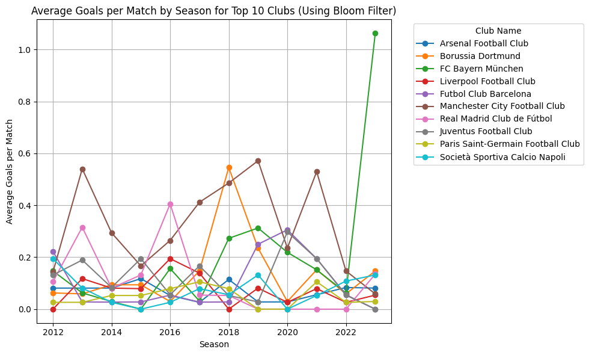

```python
import matplotlib.pyplot as plt
import pandas as pd

# Convertir le DataFrame Spark en DataFrame pandas
top_clubs_by_year_pandas = top_clubs_by_year_bloom.toPandas()

# Créer le graphique avec matplotlib
plt.figure(figsize=(10, 6))

# Tracer les lignes pour chaque club
for club in top_clubs_by_year_pandas['club_name'].unique():
    club_data = top_clubs_by_year_pandas[top_clubs_by_year_pandas['club_name'] == club]
    plt.plot(
        club_data['season'],
        club_data['average_goals_per_match'],
        marker='o',
        label=club
    )

# Ajouter le titre et les labels
plt.title('Average Goals per Match by Season for Top 10 Clubs (Using Bloom Filter)')
plt.xlabel('Season')
plt.ylabel('Average Goals per Match')

# Activer la légende
plt.legend(title="Club Name", bbox_to_anchor=(1.05, 1), loc='upper left')

# Activer le mode interactif de hover en utilisant plt.grid et plt.tight_layout
plt.grid(True)
plt.tight_layout()

# Afficher le graphique
plt.show()
```

### EXACT COUNT

```python
# TOP 10 EVOLUTION GOAL AVERAGE IN THEIR PRINCIPAL COMPETITION SINCE 2012
top_5_leagues = ['FR1', 'IT1', 'GB1', 'L1', 'ES1']
df_top_5_leagues = df_clubs_total.filter(F.col("competition_id").isin(top_5_leagues))

top_club_ids = [row['club_id'] for row in top_clubs_total.collect()]

# temps d'exécution
start_time_no_bloom = time.time()

top_clubs_by_year_exact = df_top_5_leagues.filter(F.col("club_id").isin(top_club_ids)) \
    .groupBy("club_id", "club_name", "season") \
    .agg(
        F.sum("goals").alias("total_goals"),
        F.countDistinct("game_id").alias("total_matches"), # bc games id are duplicated
        F.sum("assists").alias("total_assists")
    ) \
    .withColumn("average_goals_per_match", F.col("total_goals") / F.col("total_matches")) \
    .filter(F.col("season") != 2024) \
    .orderBy("club_id", "season")

end_time_no_bloom = time.time()
time_no_bloom = end_time_no_bloom - start_time_no_bloom

print(f"Temps d'exécution sans le filtre de Bloom (countDistinct) : {time_no_bloom:.2f} secondes")
```

```
Temps d'exécution sans le filtre de Bloom (countDistinct) : 0.27 secondes
```

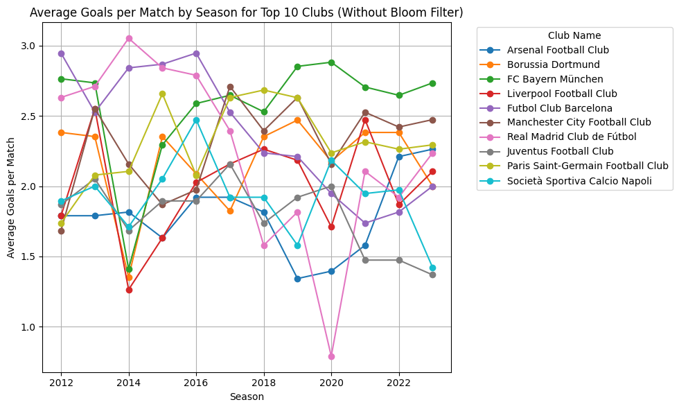

```python
import matplotlib.pyplot as plt
import pandas as pd

# Convertir le DataFrame Spark en DataFrame Pandas
top_clubs_by_year_exact_pandas = top_clubs_by_year_exact.toPandas()

# Créer le graphique avec Matplotlib
plt.figure(figsize=(10, 6))

# Tracer les lignes pour chaque club
for club in top_clubs_by_year_exact_pandas['club_name'].unique():
    club_data = top_clubs_by_year_exact_pandas[top_clubs_by_year_exact_pandas['club_name'] == club]
    plt.plot(
        club_data['season'],
        club_data['average_goals_per_match'],
        marker='o',  # Ajouter des marqueurs à chaque point
        label=club
    )

# Ajouter un titre et les labels des axes
plt.title('Average Goals per Match by Season for Top 10 Clubs (Without Bloom Filter)')
plt.xlabel('Season')
plt.ylabel('Average Goals per Match')

# Ajouter la légende
plt.legend(title="Club Name", bbox_to_anchor=(1.05, 1), loc='upper left')

# Ajouter une grille pour améliorer la lisibilité
plt.grid(True)

# Ajuster la mise en page pour éviter les chevauchements
plt.tight_layout()

# Afficher le graphique
plt.show()
```

### Comparing the results

```python
from pyspark.sql import functions as F
from pyspark.sql import Window

# Calcul de la moyenne et de la variance pour la méthode avec le filtre de Bloom
mean_bloom = top_clubs_by_year_bloom.agg(F.mean('average_goals_per_match')).collect()[0][0]
variance_bloom = top_clubs_by_year_bloom.agg(F.variance('average_goals_per_match')).collect()[0][0]

# Pour la médiane, il faut utiliser une fenêtre et calculer la valeur médiane manuellement
window_spec = Window.orderBy('average_goals_per_match')
count_bloom = top_clubs_by_year_bloom.count()

if count_bloom % 2 == 0:
    # Si le nombre de lignes est pair, la médiane est la moyenne des deux valeurs centrales
    median_bloom = top_clubs_by_year_bloom.withColumn('row_num', F.row_number().over(window_spec)) \
        .filter((F.col('row_num') == count_bloom // 2) | (F.col('row_num') == count_bloom // 2 + 1)) \
        .agg(F.mean('average_goals_per_match')).collect()[0][0]
else:
    # Si le nombre de lignes est impair, la médiane est la valeur centrale
    median_bloom = top_clubs_by_year_bloom.withColumn('row_num', F.row_number().over(window_spec)) \
        .filter(F.col('row_num') == (count_bloom // 2) + 1) \
        .select('average_goals_per_match').collect()[0][0]

print(f"Moyenne (avec filtre de Bloom) : {mean_bloom}")
print(f"Médiane (avec filtre de Bloom) : {median_bloom}")
print(f"Variance (avec filtre de Bloom) : {variance_bloom}")

# Calcul de la moyenne et de la variance pour la méthode sans le filtre de Bloom
mean_no_bloom = top_clubs_by_year_exact.agg(F.mean('average_goals_per_match')).collect()[0][0]
variance_no_bloom = top_clubs_by_year_exact.agg(F.variance('average_goals_per_match')).collect()[0][0]

count_no_bloom = top_clubs_by_year_exact.count()

if count_no_bloom % 2 == 0:
    median_no_bloom = top_clubs_by_year_exact.withColumn('row_num', F.row_number().over(window_spec)) \
        .filter((F.col('row_num') == count_no_bloom // 2) | (F.col('row_num') == count_no_bloom // 2 + 1)) \
        .agg(F.mean('average_goals_per_match')).collect()[0][0]
else:
    median_no_bloom = top_clubs_by_year_exact.withColumn('row_num', F.row_number().over(window_spec)) \
        .filter(F.col('row_num') == (count_no_bloom // 2) + 1) \
        .select('average_goals_per_match').collect()[0][0]

print(f"Moyenne (sans filtre de Bloom) : {mean_no_bloom}")
print(f"Médiane (sans filtre de Bloom) : {median_no_bloom}")
print(f"Variance (sans filtre de Bloom) : {variance_no_bloom}")
```

```
Moyenne (avec filtre de Bloom) : 0.1260941905867409
Médiane (avec filtre de Bloom) : 0.08108108108108109
Variance (avec filtre de Bloom) : 0.022789639176610425
Moyenne (sans filtre de Bloom) : 2.1479713717845814
Médiane (sans filtre de Bloom) : 2.1578947368421053
Variance (sans filtre de Bloom) : 0.1933644139192156
```

#### 1. **Moyenne :**

- **Avec le filtre de Bloom :** La moyenne des buts par match est très faible (0.126).
- **Sans le filtre de Bloom :** La moyenne est beaucoup plus élevée (2.15)
- **Pourquoi** ? Le filtre de Bloom pourrait supprimer trop de `game_id` lors de la déduplication, ce qui entraînerait une sous-estimation du nombre de matchs, et donc une moyenne des buts par match beaucoup plus faible.

À l'inverse, la méthode sans le filtre de Bloom avec `countDistinct` semble plus fiable pour capturer les tendances réelles des données, car elle donne une moyenne plus raisonnable.

#### 2. **Médiane :**

- **Avec le filtre de Bloom :** La médiane est très basse (0.081), ce qui confirme que la majorité des observations sont faibles, renforçant l'idée que le filtre de Bloom pourrait éliminer trop de matchs.
- **Sans le filtre de Bloom :** La médiane est très proche de la moyenne (2.16), ce qui montre que les données sont plus équilibrées sans la méthode du filtre de Bloom.

#### 3. **Variance :**

- **Avec le filtre de Bloom :** La variance est très faible (0.022), ce qui indique que les valeurs sont très proches les unes des autres et que les variations saisonnières sont presque inexistantes. Cela pourrait être dû à une réduction artificielle de la plage de données causée par l'élimination de trop de doublons.
- **Sans le filtre de Bloom :** La variance est plus élevée (0.193), ce qui est logique compte tenu de la distribution plus large des buts moyens par match. Cela montre qu'il y a des variations significatives d'une saison à l'autre pour certains clubs, ce qui reflète mieux la réalité du football.

#### 4. **Temps d'éxécution :**

- 0.11 secondes pour le filtre de bloom
- 0.27 secondes pour l'exact count

### Conclusion :

1. **Le filtre de Bloom semble trop agressif** dans l'élimination des doublons dans cette configuration. Cela pourrait être dû à une mauvaise configuration du filtre (capacité trop faible ou probabilité d'erreur trop élevée), entraînant la suppression de données valides malgré des résultats plus rapides.
2. **L'utilisation de `countDistinct` donne des résultats plus cohérents**, avec des valeurs plus réalistes pour la moyenne, la médiane et la variance des buts par match. Dans ce cas précis, `countDistinct` est une méthode plus fiable pour gérer les doublons dans un temps relativement raisonnable.
3. Malgré le temps d'éxécution plus rapide avec le filtre de bloom, l'utilisation du countDistinct semble clairement plus adapté.

## Average Market Value of a team in each League

```python
from pyspark.sql import functions as F

# AVERAGE COST OF A TEAM IN EACH LEAGUE
clubs_cost_per_year = df_clubs_players_cost.groupBy(
    "club_id",
    "club_name",
    "player_last_season",
    "domestic_competition_id",
    "country_name"

).agg(
    F.sum("market_value_in_eur").alias("total_market_value_in_eur"),
)

average_market_value_per_league = clubs_cost_per_year.groupBy(
    "domestic_competition_id",
    "country_name"
).agg(
    F.avg("total_market_value_in_eur").alias("average_market_value_in_eur")  # Average market value per league
)

average_market_value_per_league_ordered = average_market_value_per_league.orderBy(
    F.desc("average_market_value_in_eur")
)

average_market_value_per_league_ordered = average_market_value_per_league_ordered \
    .withColumn("flag_url", get_flag_url_udf(F.col("country_name")))

average_market_value_per_league_ordered.show(truncate=False)
```

```
+-----------------------+------------+---------------------------+------------------------------------------------------------------+
|domestic_competition_id|country_name|average_market_value_in_eur|flag_url                                                          |
+-----------------------+------------+---------------------------+------------------------------------------------------------------+
|GB1                    |England     |5.471596E7                 |https://upload.wikimedia.org/wikipedia/en/b/be/Flag_of_England.svg|
|ES1                    |Spain       |2.6162217741935484E7       |https://upload.wikimedia.org/wikipedia/en/9/9a/Flag_of_Spain.svg  |
|IT1                    |Italy       |2.4532576923076924E7       |https://upload.wikimedia.org/wikipedia/en/0/03/Flag_of_Italy.svg  |
|L1                     |Germany     |2.2953246753246754E7       |https://upload.wikimedia.org/wikipedia/en/b/ba/Flag_of_Germany.svg|
|FR1                    |France      |1.909073705179283E7        |https://upload.wikimedia.org/wikipedia/en/c/c3/Flag_of_France.svg |
+-----------------------+------------+---------------------------+------------------------------------------------------------------+
```

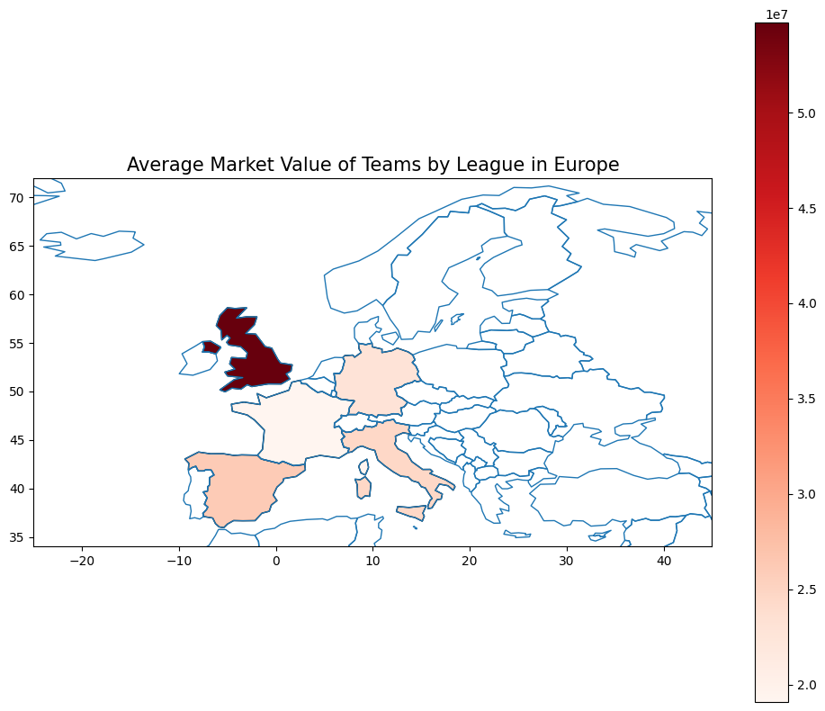

```python
import geopandas as gpd
import matplotlib.pyplot as plt
import pandas as pd

# Charger les données GeoJSON
world = gpd.read_file('https://raw.githubusercontent.com/johan/world.geo.json/master/countries.geo.json')

# Convertir les données Spark en pandas DataFrame
average_market_value_pandas = average_market_value_per_league_ordered.toPandas()
average_market_value_pandas['iso_alpha'] = ['GBR', 'ESP', 'ITA', 'DEU', 'FRA']

# Associer les codes ISO aux pays du GeoJSON
world = world.merge(average_market_value_pandas, left_on='id', right_on='iso_alpha', how='left')

# Configurer la figure et les axes
fig, ax = plt.subplots(1, 1, figsize=(10, 8))

# Tracer les pays, et colorier selon la valeur moyenne du marché
world.boundary.plot(ax=ax, linewidth=1)
world.plot(column='average_market_value_in_eur', ax=ax, legend=True,
           cmap='Reds', edgecolor='black')

# Zoom sur l'Europe (approximation des limites de longitude et latitude)
ax.set_xlim([-25, 45])  # Limites pour la longitude
ax.set_ylim([34, 72])   # Limites pour la latitude

# Ajouter des titres et ajuster les marges
plt.title("Average Market Value of Teams by League in Europe", fontsize=15)
plt.tight_layout()

# Afficher la carte
plt.show()
```

# Champions League Winner Prediction

we get champions league games only

```python
from pyspark.sql import functions as F
# we join
df_joined = df_games.join(
    df_club_games,
    on="game_id",
    how="inner"
).select(
    df_games["game_id"],
    df_games["competition_id"],
    df_games["season"],
    df_games["round"],
    df_games["date"],
    df_games["home_club_id"],
    df_games["away_club_id"],
    df_games["home_club_goals"],
    df_games["away_club_goals"],
    df_games["home_club_formation"],
    df_games["away_club_formation"],
    df_games["home_club_name"],
    df_games["away_club_name"],
    df_games["competition_type"],
    df_club_games["club_id"],
    df_club_games["hosting"],
    df_club_games["is_win"]
)

# we study only champions league games
df_cl = df_joined.filter(F.col("competition_id") == "CL")
```

```python
df_cl.show()
```

```
+-------+--------------+------+--------------------+----------+------------+------------+---------------+---------------+-------------------+-------------------+--------------------+--------------------+-----------------+-------+-------+------+
|game_id|competition_id|season|               round|      date|home_club_id|away_club_id|home_club_goals|away_club_goals|home_club_formation|away_club_formation|      home_club_name|      away_club_name| competition_type|club_id|hosting|is_win|
+-------+--------------+------+--------------------+----------+------------+------------+---------------+---------------+-------------------+-------------------+--------------------+--------------------+-----------------+-------+-------+------+
|2368466|            CL|  2013|             Group H|2013-11-26|         371|           5|              0|              3|            4-2-3-1|            4-3-2-1|The Celtic Footba...|Associazione Calc...|international_cup|      5|   Away|     1|
|2368466|            CL|  2013|             Group H|2013-11-26|         371|           5|              0|              3|            4-2-3-1|            4-3-2-1|The Celtic Footba...|Associazione Calc...|international_cup|    371|   Home|     0|
|2368481|            CL|  2013|             Group C|2013-12-10|         683|          58|              3|              1|            4-4-1-1|            4-1-4-1|Olympiakos Syndes...|Royal Sporting Cl...|international_cup|     58|   Away|     0|
|2368481|            CL|  2013|             Group C|2013-12-10|         683|          58|              3|              1|            4-4-1-1|            4-1-4-1|Olympiakos Syndes...|Royal Sporting Cl...|international_cup|    683|   Home|     1|
|2384520|            CL|  2013|             Group B|2013-12-11|         141|         506|              1|              0|              3-5-2|         3-5-2 flat|Galatasaray Spor ...|Juventus Football...|international_cup|    506|   Away|     0|
|2384520|            CL|  2013|             Group B|2013-12-11|         141|         506|              1|              0|              3-5-2|         3-5-2 flat|Galatasaray Spor ...|Juventus Football...|international_cup|    141|   Home|     1|
|2490853|            CL|  2014|             Group F|2014-09-17|         610|         583|              1|              1|    4-3-3 Attacking|    4-3-3 Attacking|  AFC Ajax Amsterdam|Paris Saint-Germa...|international_cup|    583|   Away|     0|
|2490853|            CL|  2014|             Group F|2014-09-17|         610|         583|              1|              1|    4-3-3 Attacking|    4-3-3 Attacking|  AFC Ajax Amsterdam|Paris Saint-Germa...|international_cup|    610|   Home|     0|
|2495311|            CL|  2014|             Group E|2014-10-21|          12|          27|              1|              7|    4-3-3 Attacking|              3-5-2|Associazione Spor...|   FC Bayern München|international_cup|     27|   Away|     1|
|2495311|            CL|  2014|             Group E|2014-10-21|          12|          27|              1|              7|    4-3-3 Attacking|              3-5-2|Associazione Spor...|   FC Bayern München|international_cup|     12|   Home|     0|
|2495365|            CL|  2014|             Group D|2014-12-09|          16|          58|              1|              1|            4-2-3-1|            4-2-3-1|   Borussia Dortmund|Royal Sporting Cl...|international_cup|     58|   Away|     0|
|2495365|            CL|  2014|             Group D|2014-12-09|          16|          58|              1|              1|            4-2-3-1|            4-2-3-1|   Borussia Dortmund|Royal Sporting Cl...|international_cup|     16|   Home|     0|
|2618544|            CL|  2015|             Group E|2015-09-16|          12|         131|              1|              1|    4-3-3 Attacking|    4-3-3 Attacking|Associazione Spor...|Futbol Club Barce...|international_cup|    131|   Away|     0|
|2618544|            CL|  2015|             Group E|2015-09-16|          12|         131|              1|              1|    4-3-3 Attacking|    4-3-3 Attacking|Associazione Spor...|Futbol Club Barce...|international_cup|     12|   Home|     0|
|2618567|            CL|  2015|             Group B|2015-09-30|         985|          82|              2|              1|            4-2-3-1|            4-2-3-1|Manchester United...|Verein für Leibes...|international_cup|     82|   Away|     0|
|2618567|            CL|  2015|             Group B|2015-09-30|         985|          82|              2|              1|            4-2-3-1|            4-2-3-1|Manchester United...|Verein für Leibes...|international_cup|    985|   Home|     1|
|2675294|            CL|  2015|Quarter-Finals 1s...|2016-04-05|          27|         294|              1|              0|     4-4-2 double 6|     4-4-2 double 6|   FC Bayern München|Sport Lisboa e Be...|international_cup|    294|   Away|     0|
|2675294|            CL|  2015|Quarter-Finals 1s...|2016-04-05|          27|         294|              1|              0|     4-4-2 double 6|     4-4-2 double 6|   FC Bayern München|Sport Lisboa e Be...|international_cup|     27|   Home|     1|
|2675295|            CL|  2015|Quarter-Finals 1s...|2016-04-05|         131|          13|              2|              1|    4-3-3 Attacking|     4-4-2 double 6|Futbol Club Barce...|Club Atlético de ...|international_cup|     13|   Away|     0|
|2675295|            CL|  2015|Quarter-Finals 1s...|2016-04-05|         131|          13|              2|              1|    4-3-3 Attacking|     4-4-2 double 6|Futbol Club Barce...|Club Atlético de ...|international_cup|    131|   Home|     1|
+-------+--------------+------+--------------------+----------+------------+------------+---------------+---------------+-------------------+-------------------+--------------------+--------------------+-----------------+-------+-------+------+
only showing top 20 rows
```

## Estimate home draw defeat win probability w/ Poisson law

for the first approach, i decided to estimate the draw, defeat or win probability using Poisson distribution. The probability is calculated based on the ajusted average goal of a team.

```python
from pyspark.sql import SparkSession
from pyspark.sql.functions import col, lit, udf
from pyspark.sql.types import DoubleType, ArrayType
from scipy.stats import poisson
import numpy as np

# the average goals scored and conceded by each team
team_stats = df_cl.groupBy("home_club_id").agg(
    {'home_club_goals': 'avg', 'away_club_goals': 'avg'}
).withColumnRenamed("avg(home_club_goals)", "home_avg_goals_scored") \
 .withColumnRenamed("avg(away_club_goals)", "home_avg_goals_conceded")

# same for away teams
team_stats_away = df_cl.groupBy("away_club_id").agg(
    {'away_club_goals': 'avg', 'home_club_goals': 'avg'}
).withColumnRenamed("avg(away_club_goals)", "away_avg_goals_scored") \
 .withColumnRenamed("avg(home_club_goals)", "away_avg_goals_conceded")

# merge the home and away statistics
team_stats = team_stats.join(team_stats_away, team_stats.home_club_id == team_stats_away.away_club_id)

# we add value coefficients to the dataset to give more importance to scored goals than conceded ones.
coeff_scored = 1.29
coeff_conceded = 0.79

team_stats = team_stats.withColumn("adjusted_home_avg_goals_scored", col("home_avg_goals_scored") * coeff_scored) \
    .withColumn("adjusted_home_avg_goals_conceded", col("home_avg_goals_conceded") * coeff_conceded) \
    .withColumn("adjusted_away_avg_goals_scored", col("away_avg_goals_scored") * coeff_scored) \
    .withColumn("adjusted_away_avg_goals_conceded", col("away_avg_goals_conceded") * coeff_conceded)
```

Here we have the probabilitily for each team to score 0 to 4 goals when they are playing home or away. Usually the probability are higher when the team is home.

```python
from pyspark.sql.functions import col, udf
from pyspark.sql.types import ArrayType, DoubleType
from scipy.stats import poisson

# udf function to calculate poisson probability (0 to 4 goals)
def poisson_probabilities(avg_goals):
    return [float(poisson.pmf(x, avg_goals)) for x in range(5)]

# register the udf
poisson_udf = udf(poisson_probabilities, ArrayType(DoubleType()))

# we apply it
team_stats = team_stats.withColumn("home_poisson_probs", poisson_udf(col("adjusted_home_avg_goals_scored"))) \
                       .withColumn("away_poisson_probs", poisson_udf(col("adjusted_away_avg_goals_scored")))

team_stats.select("home_club_id", "home_poisson_probs", "away_poisson_probs").show(truncate=False)
```

```
+------------+----------------------------------------------------------------------------------------------------------+-----------------------------------------------------------------------------------------------------------+
|home_club_id|home_poisson_probs                                                                                        |away_poisson_probs                                                                                         |
+------------+----------------------------------------------------------------------------------------------------------+-----------------------------------------------------------------------------------------------------------+
|148         |[0.09580364512050978, 0.22470309491901383, 0.26351544767775253, 0.20602116818442467, 0.12080332134450354] |[0.1583643096497964, 0.2918427992117676, 0.2689122935594145, 0.16518898032935464, 0.07610492308030979]     |
|496         |[0.5636434922238741, 0.3231556022083545, 0.0926379392997283, 0.017704139510614742, 0.002537593329854779]  |[0.7507619411130763, 0.21521842311908185, 0.03084797398040173, 0.002947695291460608, 2.1125149588801015E-4]|
|1084        |[0.12694517228885002, 0.2620148356041864, 0.2703993103435204, 0.18603472551634204, 0.09599391836643248]   |[0.12694517228885002, 0.2620148356041864, 0.2703993103435204, 0.18603472551634204, 0.09599391836643248]    |
|31          |[0.07303203175886415, 0.19111439396555335, 0.2500595334757862, 0.21812335877187866, 0.14269941735654545]  |[0.06111487433258836, 0.17081607375958444, 0.23871546307901922, 0.22240323976861956, 0.1554042637883229]   |
|255         |[0.17906614791149322, 0.3079937744077683, 0.2648746459906808, 0.15186146370132367, 0.06530042939156919]   |[0.11648415777349691, 0.2504409392130184, 0.2692240096539949, 0.19294387358536305, 0.10370733205213263]    |
|6890        |[0.11648415777349691, 0.2504409392130184, 0.2692240096539949, 0.19294387358536305, 0.10370733205213263]   |[0.4231620823177488, 0.36391939079326396, 0.15648533804110354, 0.04485913023844967, 0.009644713001266673]  |
|683         |[0.16239441004903907, 0.2951887480845942, 0.2682863189977937, 0.1625571196472996, 0.07387112743972171]    |[0.3095216391797345, 0.362984467765325, 0.21284089246239507, 0.08320143978075444, 0.024393149390266645]    |
|368         |[0.12694517228885002, 0.2620148356041864, 0.2703993103435204, 0.18603472551634204, 0.09599391836643248]   |[0.30519633138737323, 0.3622070060905346, 0.21493363741412325, 0.08502774696102716, 0.02522773252333677]   |
|762         |[0.11648415777349691, 0.2504409392130184, 0.2692240096539949, 0.19294387358536305, 0.10370733205213263]   |[0.6505090947233165, 0.2797189107310261, 0.06013956580717059, 0.00862000443236112, 9.26650476478821E-4]    |
|2778        |[0.27527078308975234, 0.3550993101857805, 0.22903905506982844, 0.09848679368002622, 0.03176199096180845]  |[0.6505090947233165, 0.2797189107310261, 0.06013956580717059, 0.00862000443236112, 9.26650476478821E-4]    |
|1064        |[0.17906614791149322, 0.3079937744077683, 0.2648746459906808, 0.15186146370132367, 0.06530042939156919]   |[0.27527078308975234, 0.3550993101857805, 0.22903905506982844, 0.09848679368002622, 0.03176199096180845]   |
|27          |[0.024019092357322754, 0.08956494361054802, 0.16698963900513508, 0.20756290285716397, 0.19349565143305542]|[0.06268043745410797, 0.17360637632509845, 0.24041930086080174, 0.2219635839417814, 0.15369346102792314]   |
|26          |[0.19041080132774185, 0.31580991477358333, 0.2618966507515216, 0.14479143405834125, 0.06003673390776221]  |[0.36292051756394905, 0.36784586744517406, 0.18641903068025073, 0.06298300107982756, 0.015959442595049163] |
|159         |[0.20666282744417896, 0.3258383912703222, 0.25686926511810404, 0.1349990693342925, 0.053212133162600275]  |[0.5636434922238741, 0.3231556022083545, 0.0926379392997283, 0.017704139510614742, 0.002537593329854779]   |
|336         |[0.12291650195797872, 0.2576637172294129, 0.27006378362107836, 0.18870706880522856, 0.09889429824574007]  |[0.18394380051696735, 0.31143984725029034, 0.2636532956878239, 0.1487993287538156, 0.06298396587407601]    |
|12          |[0.08819232886093943, 0.2141517256105635, 0.2600053892118841, 0.21045142091503097, 0.12775639199077168]   |[0.188357831781853, 0.31444678035111695, 0.2624705772460205, 0.14605715651455026, 0.06095738385121964]     |
|409         |[0.156550756327709, 0.29030380876519535, 0.2691660626894796, 0.16637827249993462, 0.07713192726676654]    |[0.16969543627547695, 0.3009972800936273, 0.26694696278303576, 0.15783239174546984, 0.06998880121463179]   |
|190         |[0.24926697472966367, 0.3462893510475174, 0.24053791076608322, 0.11138755560090928, 0.03868575488754657]  |[0.4521025909181191, 0.35889990294422996, 0.14245565378401745, 0.03769595761669384, 0.007481197742390007]  |
|232         |[0.09394930036847922, 0.22219009537145337, 0.26273978777674356, 0.2071265326973328, 0.12246356245729799]  |[0.3412977553009936, 0.3668950869485682, 0.19720610923485546, 0.07066552247582321, 0.018991359165377485]   |
|157         |[0.14442426882354198, 0.2794609601735537, 0.2703784789679132, 0.17439411893430407, 0.08436315503446959]   |[0.27527078308975234, 0.3550993101857805, 0.22903905506982844, 0.09848679368002622, 0.03176199096180845]   |
+------------+----------------------------------------------------------------------------------------------------------+-----------------------------------------------------------------------------------------------------------+
only showing top 20 rows
```

The create_probability_matrix function generates a 5x5 probability matrix (as we are dealing with 0 to 4 goals). Each element in the matrix represents the joint probability that the home team scores X goals and the away team scores Y goals. Since the probabilities are independent, each element in the matrix is calculated by multiplying the probability that the home team scores X goals by the probability that the away team scores Y goals. For example, matrix[0][0] represents the probability that both teams score 0 goals, and matrix[4][4] represents the probability that both teams score 4 goals. The matrix is then used to calculate the probabilities of a home win (sum of the elements below the diagonal), a draw (diagonal elements), and an away win (sum of the elements above the diagonal).

```python
def create_probability_matrix(home_probs, away_probs):
    matrix = []
    for home_prob in home_probs:
        row = []
        for away_prob in away_probs:
            row.append(home_prob * away_prob)  # Simply multiply the probabilities because independant
        matrix.append(row)
    return matrix

# register the UDF
probability_matrix_udf = udf(create_probability_matrix, ArrayType(ArrayType(DoubleType())))
team_stats = team_stats.withColumn("probability_matrix", probability_matrix_udf(col("home_poisson_probs"), col("away_poisson_probs")))

# UDF to calculate match outcomes probability for each team (home win, draw, away win)
def calculate_match_outcomes(matrix):
    home_win_prob = sum([sum(row[:i]) for i, row in enumerate(matrix)])  # sum of lower triangular matrix for home wins
    draw_prob = sum(matrix[i][i] for i in range(len(matrix)))  # diagonal for draws
    away_win_prob = sum([sum(row[i+1:]) for i, row in enumerate(matrix)])  # sum of upper triangular matrix for away wins
    return (home_win_prob, draw_prob, away_win_prob)

# register the UDF for match outcomes
match_outcomes_udf = udf(calculate_match_outcomes, ArrayType(DoubleType()))

# apply the UDF to calculate match outcomes (home win, draw, away win)
team_stats = team_stats.withColumn("match_outcomes", match_outcomes_udf(col("probability_matrix")))
```

```python
team_stats.select("home_club_id", "probability_matrix", "match_outcomes").show(10, truncate=True)
```

```
+------------+--------------------+--------------------+
|home_club_id|  probability_matrix|      match_outcomes|
+------------+--------------------+--------------------+
|         148|[[0.0151718781214...|[0.40920268742226...|
|         496|[[0.4231620823177...|[0.35228437050379...|
|        1084|[[0.0161150767674...|[0.34225245294175...|
|          31|[[0.0044633434431...|[0.27123323423573...|
|         255|[[0.0208583694252...|[0.28381221266177...|
|        6890|[[0.0492916787604...|[0.60244079229332...|
|         683|[[0.0502645839920...|[0.48725871640525...|
|         368|[[0.0387432008698...|[0.51743781584754...|
|         762|[[0.0757740040228...|[0.70804151387093...|
|        2778|[[0.1790661479114...|[0.57332183518294...|
+------------+--------------------+--------------------+
only showing top 10 rows
```

The main problem of this approach is that we don't take in account the last result of a team (for example if the team is on a winning streak), we only consider the average. Elo is more adapted to take the last eprformances of a team in account.

## Estimate home draw or win probability w/ Score Elo

```python
from pyspark.sql.types import DateType

# we filter to only keep Home games (because games are duplicated when they are away) & we make sure there is no NULL teams
df_cl = df_cl.filter(df_cl['hosting'] == 'Home')
df_cl = df_cl.filter(df_cl['home_club_name'].isNotNull() & df_cl['away_club_name'].isNotNull())
df_cl.show()
```

```
+-------+--------------+------+--------------------+----------+------------+------------+---------------+---------------+-------------------+-------------------+--------------------+--------------------+-----------------+-------+-------+------+
|game_id|competition_id|season|               round|      date|home_club_id|away_club_id|home_club_goals|away_club_goals|home_club_formation|away_club_formation|      home_club_name|      away_club_name| competition_type|club_id|hosting|is_win|
+-------+--------------+------+--------------------+----------+------------+------------+---------------+---------------+-------------------+-------------------+--------------------+--------------------+-----------------+-------+-------+------+
|2368466|            CL|  2013|             Group H|2013-11-26|         371|           5|              0|              3|            4-2-3-1|            4-3-2-1|The Celtic Footba...|Associazione Calc...|international_cup|    371|   Home|     0|
|2368481|            CL|  2013|             Group C|2013-12-10|         683|          58|              3|              1|            4-4-1-1|            4-1-4-1|Olympiakos Syndes...|Royal Sporting Cl...|international_cup|    683|   Home|     1|
|2384520|            CL|  2013|             Group B|2013-12-11|         141|         506|              1|              0|              3-5-2|         3-5-2 flat|Galatasaray Spor ...|Juventus Football...|international_cup|    141|   Home|     1|
|2490853|            CL|  2014|             Group F|2014-09-17|         610|         583|              1|              1|    4-3-3 Attacking|    4-3-3 Attacking|  AFC Ajax Amsterdam|Paris Saint-Germa...|international_cup|    610|   Home|     0|
|2495311|            CL|  2014|             Group E|2014-10-21|          12|          27|              1|              7|    4-3-3 Attacking|              3-5-2|Associazione Spor...|   FC Bayern München|international_cup|     12|   Home|     0|
|2495365|            CL|  2014|             Group D|2014-12-09|          16|          58|              1|              1|            4-2-3-1|            4-2-3-1|   Borussia Dortmund|Royal Sporting Cl...|international_cup|     16|   Home|     0|
|2618544|            CL|  2015|             Group E|2015-09-16|          12|         131|              1|              1|    4-3-3 Attacking|    4-3-3 Attacking|Associazione Spor...|Futbol Club Barce...|international_cup|     12|   Home|     0|
|2618567|            CL|  2015|             Group B|2015-09-30|         985|          82|              2|              1|            4-2-3-1|            4-2-3-1|Manchester United...|Verein für Leibes...|international_cup|    985|   Home|     1|
|2675294|            CL|  2015|Quarter-Finals 1s...|2016-04-05|          27|         294|              1|              0|     4-4-2 double 6|     4-4-2 double 6|   FC Bayern München|Sport Lisboa e Be...|international_cup|     27|   Home|     1|
|2675295|            CL|  2015|Quarter-Finals 1s...|2016-04-05|         131|          13|              2|              1|    4-3-3 Attacking|     4-4-2 double 6|Futbol Club Barce...|Club Atlético de ...|international_cup|    131|   Home|     1|
|2754918|            CL|  2016|             Group C|2016-10-19|         371|          18|              0|              2|            4-2-3-1|            4-2-3-1|The Celtic Footba...|Borussia Verein f...|international_cup|    371|   Home|     0|
|2917360|            CL|  2017|             Group B|2017-09-12|         371|         583|              0|              5|            4-2-3-1|    4-3-3 Attacking|The Celtic Footba...|Paris Saint-Germa...|international_cup|    371|   Home|     0|
|2917362|            CL|  2017|             Group C|2017-09-12|          12|          13|              0|              0|            4-1-4-1|              4-4-2|Associazione Spor...|Club Atlético de ...|international_cup|     12|   Home|     0|
|2917391|            CL|  2017|             Group B|2017-10-18|          58|         583|              0|              4|            3-4-2-1|    4-3-3 Attacking|Royal Sporting Cl...|Paris Saint-Germa...|international_cup|     58|   Home|     0|
|2917441|            CL|  2017|             Group C|2017-12-05|         631|          13|              1|              1|         3-5-2 flat|              4-4-2|Chelsea Football ...|Club Atlético de ...|international_cup|    631|   Home|     0|
|2367096|            CL|  2013|             Group F|2013-09-18|        6195|          16|              2|              1|            4-2-3-1|            4-2-3-1|Società Sportiva ...|   Borussia Dortmund|international_cup|   6195|   Home|     1|
|2368442|            CL|  2013|             Group B|2013-10-23|         141|         190|              3|              1|            4-2-3-1|              4-4-2|Galatasaray Spor ...|Football Club Køb...|international_cup|    141|   Home|     1|
|2368487|            CL|  2013|             Group F|2013-12-11|         244|          16|              1|              2|            4-2-3-1|            4-2-3-1|Olympique de Mars...|   Borussia Dortmund|international_cup|    244|   Home|     0|
|2385041|            CL|  2013|     last 16 1st leg|2014-02-26|         141|         631|              1|              1|     4-4-2 double 6|            4-2-3-1|Galatasaray Spor ...|Chelsea Football ...|international_cup|    141|   Home|     0|
|2495322|            CL|  2014|             Group C|2014-10-22|         162|         294|              0|              0|    4-3-3 Defending|            4-1-3-2|Association sport...|Sport Lisboa e Be...|international_cup|    162|   Home|     0|
+-------+--------------+------+--------------------+----------+------------+------------+---------------+---------------+-------------------+-------------------+--------------------+--------------------+-----------------+-------+-------+------+
only showing top 20 rows
```

```python
from pyspark.sql import SparkSession
from pyspark.sql.functions import col, when, lit
import math

# first elo score
initial_elo = 1500

# we create a dictionnary of teams's info
team_info = {
    row["home_club_id"]: {
        "team_name": row["home_club_name"],
        "team_id": row["home_club_id"],
        "elo_score": initial_elo,
        "last_round": None,
        "last_year": None,
        "victories": 0
    }
    for row in df_cl.select("home_club_id", "home_club_name").distinct().collect()
}

# Broadcasting of elo's score dictionnary
broadcast_team_info = spark.sparkContext.broadcast(team_info)

# we get the probability of winning (E)
def expected_win(elo_a, elo_b):
    return 1 / (1 + 10**((elo_b - elo_a) / 400))

# function to update the elo score and the team's info
def update_team_info(home_team, away_team, home_goals, away_goals, season, round_name, is_win, broadcast_team_info):
    K = 20  # Factor K to adjust

    # get the current info
    home_info = broadcast_team_info.value.get(home_team)
    away_info = broadcast_team_info.value.get(away_team)

    # get the current score
    home_elo = home_info["elo_score"]
    away_elo = away_info["elo_score"]

    # calculate the proba
    E_home = expected_win(home_elo, away_elo)
    E_away = expected_win(away_elo, home_elo)

    # results
    if home_goals > away_goals:
        result_home = 1  # win
        result_away = 0
        home_info["victories"] += 1
    elif home_goals < away_goals:
        result_home = 0  # defeat
        result_away = 1
        away_info["victories"] += 1
    else:
        result_home = 0.5  # draw
        result_away = 0.5

    # Mise à jour des scores Elo
    new_home_elo = home_elo + K * (result_home - E_home)
    new_away_elo = away_elo + K * (result_away - E_away)

    # updating
    home_info["elo_score"] = new_home_elo
    away_info["elo_score"] = new_away_elo

    home_info["last_year"] = season
    away_info["last_year"] = season
    home_info["last_round"] = round_name
    away_info["last_round"] = round_name

    # updating the broadcast
    broadcast_team_info.value[home_team] = home_info
    broadcast_team_info.value[away_team] = away_info

# we order by
df = df_cl.orderBy(["season", "round", "date"])

for row in df.collect():
    update_team_info(
        row["home_club_id"],
        row["away_club_id"],
        row["home_club_goals"],
        row["away_club_goals"],
        row["season"],
        row["round"],
        row["is_win"],
        broadcast_team_info
    )

final_team_info = broadcast_team_info.value

# better way to display result
for team_id, info in final_team_info.items():
    print(f"Team: {info['team_name']} | Elo: {info['elo_score']} | "
          f"Last Round: {info['last_round']} | Last Year: {info['last_year']} | "
          f"Victories: {info['victories']}")
```

```
Team: Leicester City Football Club | Elo: 1517.7760732017996 | Last Round: last 16 2nd leg | Last Year: 2016 | Victories: 5
Team: Athlitiki Enosi Konstantinoupoleos | Elo: 1447.759899062831 | Last Round: Group E | Last Year: 2018 | Victories: 0
Team: Olympique Lyonnais | Elo: 1491.4632612942282 | Last Round: last 16 2nd leg | Last Year: 2019 | Victories: 6
Team: Sevilla Fútbol Club S.A.D. | Elo: 1462.7515164418037 | Last Round: Group B | Last Year: 2023 | Victories: 12
Team: TSG 1899 Hoffenheim Fußball-Spielbetriebs GmbH | Elo: 1470.3510057676112 | Last Round: Group F | Last Year: 2018 | Victories: 0
Team: Sporting Clube de Braga | Elo: 1467.481733738043 | Last Round: Group C | Last Year: 2023 | Victories: 2
Team: Racing Club de Lens | Elo: 1497.6324503400292 | Last Round: Group B | Last Year: 2023 | Victories: 2
Team: FC Schalke 04 | Elo: 1484.0558489331138 | Last Round: last 16 2nd leg | Last Year: 2018 | Victories: 8
Team: Juventus Football Club | Elo: 1586.9020994169534 | Last Round: Group H | Last Year: 2022 | Victories: 43
Team: FC Bayern München | Elo: 1733.7317469272548 | Last Round: last 16 2nd leg | Last Year: 2023 | Victories: 80
Team: Sporting Clube de Portugal | Elo: 1464.5796544235116 | Last Round: Group D | Last Year: 2022 | Victories: 8
Team: Real Sociedad de Fútbol S.A.D. | Elo: 1468.001800055811 | Last Round: last 16 2nd leg | Last Year: 2023 | Victories: 2
Team: Valencia Club de Fútbol S. A. D. | Elo: 1484.847034619266 | Last Round: last 16 2nd leg | Last Year: 2019 | Victories: 8
Team: Società Sportiva Calcio Napoli | Elo: 1565.8262847285985 | Last Round: last 16 2nd leg | Last Year: 2023 | Victories: 22
Team: Real Madrid Club de Fútbol | Elo: 1741.388902888293 | Last Round: last 16 2nd leg | Last Year: 2023 | Victories: 82
Team: Borussia Dortmund | Elo: 1584.2052956459097 | Last Round: last 16 2nd leg | Last Year: 2023 | Victories: 44
Team: Málaga CF | Elo: 1516.1737370500362 | Last Round: last 16 2nd leg | Last Year: 2012 | Victories: 4
Team: Sport Lisboa e Benfica | Elo: 1504.3035848376471 | Last Round: Group D | Last Year: 2023 | Victories: 24
Team: Tottenham Hotspur Football Club | Elo: 1511.9277552644944 | Last Round: last 16 2nd leg | Last Year: 2022 | Victories: 15
Team: RasenBallsport Leipzig | Elo: 1539.724348914518 | Last Round: last 16 2nd leg | Last Year: 2023 | Victories: 18
Team: Verein für Leibesübungen Wolfsburg | Elo: 1515.3031593810833 | Last Round: Group G | Last Year: 2021 | Victories: 7
Team: Manchester City Football Club | Elo: 1712.5475919402513 | Last Round: last 16 2nd leg | Last Year: 2023 | Victories: 60
Team: Futbol Club Barcelona | Elo: 1611.3596180411832 | Last Round: last 16 2nd leg | Last Year: 2023 | Victories: 60
Team: Paris Saint-Germain Football Club | Elo: 1595.6890289998096 | Last Round: last 16 2nd leg | Last Year: 2023 | Victories: 50
Team: Manchester United Football Club | Elo: 1514.0519740055242 | Last Round: Group A | Last Year: 2023 | Victories: 23
Team: Newcastle United Football Club | Elo: 1486.8711323878092 | Last Round: Group F | Last Year: 2023 | Victories: 1
Team: Atalanta Bergamasca Calcio S.p.a. | Elo: 1495.6440626259416 | Last Round: Group F | Last Year: 2021 | Victories: 6
Team: "Футбольный клуб ""Локомотив"" Москва" | Elo: 1441.0140195459933 | Last Round: Group A | Last Year: 2020 | Victories: 2
Team: Royal Sporting Club Anderlecht | Elo: 1424.4376622147963 | Last Round: Group B | Last Year: 2017 | Victories: 3
Team: Beşiktaş Jimnastik Kulübü | Elo: 1464.0431691312176 | Last Round: Group C | Last Year: 2021 | Victories: 5
Team: Club Brugge Koninklijke Voetbalvereniging | Elo: 1452.9573238243963 | Last Round: last 16 2nd leg | Last Year: 2022 | Victories: 7
Team: Royal Antwerp Football Club | Elo: 1470.0894665740466 | Last Round: Group H | Last Year: 2023 | Victories: 1
Team: Club Atlético de Madrid S.A.D. | Elo: 1561.8030728208425 | Last Round: last 16 2nd leg | Last Year: 2023 | Victories: 45
Team: Futbolniy Klub Dynamo Kyiv | Elo: 1417.3730838646534 | Last Round: Group E | Last Year: 2021 | Victories: 2
Team: Football Club Internazionale Milano S.p.A. | Elo: 1544.371186528413 | Last Round: last 16 2nd leg | Last Year: 2023 | Victories: 13
Team: Arsenal Football Club | Elo: 1541.8228237274989 | Last Round: last 16 2nd leg | Last Year: 2023 | Victories: 20
Team: Lille Olympique Sporting Club Lille Métropole | Elo: 1443.5598447646312 | Last Round: last 16 2nd leg | Last Year: 2021 | Victories: 2
Team: Olympiakos Syndesmos Filathlon Peiraios | Elo: 1419.7765701556455 | Last Round: Group C | Last Year: 2020 | Victories: 11
Team: Montpellier Hérault Sport Club | Elo: 1463.6144503851112 | Last Round: Group B | Last Year: 2012 | Victories: 0
Team: Bayer 04 Leverkusen Fußball | Elo: 1480.856329669979 | Last Round: Group B | Last Year: 2022 | Victories: 12
```

[output cut: 17 more lines]

```
Team: AO FK Zenit Sankt-Peterburg | Elo: 1433.3303957505543 | Last Round: Group H | Last Year: 2021 | Victories: 13
Team: Association sportive de Monaco Football Club | Elo: 1443.9018758544134 | Last Round: Group A | Last Year: 2018 | Victories: 10
Team: Galatasaray Spor Kulübü | Elo: 1408.4397209496465 | Last Round: Group A | Last Year: 2023 | Victories: 9
Team: The Celtic Football Club | Elo: 1387.5863713657784 | Last Round: Group E | Last Year: 2023 | Victories: 6
Team: Associazione Calcio Milan | Elo: 1487.1088828512181 | Last Round: Group F | Last Year: 2023 | Victories: 10
Team: Villarreal Club de Fútbol S.A.D. | Elo: 1519.8334492537517 | Last Round: last 16 2nd leg | Last Year: 2021 | Victories: 3
Team: Koninklijke Racing Club Genk | Elo: 1475.409353922005 | Last Round: Group E | Last Year: 2019 | Victories: 0
Team: Stade Rennais Football Club | Elo: 1455.5367676820351 | Last Round: Group E | Last Year: 2020 | Victories: 0
Team: Rangers Football Club | Elo: 1455.6860134879116 | Last Round: Group A | Last Year: 2022 | Victories: 0
Team: Eintracht Frankfurt Fußball AG | Elo: 1488.6803762155391 | Last Round: last 16 2nd leg | Last Year: 2022 | Victories: 3
Team: Fodbold Club Midtjylland | Elo: 1469.65971190308 | Last Round: Group D | Last Year: 2020 | Victories: 0
Team: 1. FC Union Berlin | Elo: 1475.3035778094593 | Last Round: Group C | Last Year: 2023 | Victories: 0
Team: FK Rostov | Elo: 1492.425149391648 | Last Round: Group D | Last Year: 2016 | Victories: 1
Team: Athletic Club Bilbao | Elo: 1489.9684599972175 | Last Round: Group H | Last Year: 2014 | Victories: 1
Team: Eindhovense Voetbalvereniging Philips Sport Vereniging | Elo: 1465.5900610781996 | Last Round: last 16 2nd leg | Last Year: 2023 | Victories: 5
```

## diving into real time prediction w/ streaming data

Étape 1 : Initialiser la liste des équipes et les scores Elo à 1500

```python
# Liste des équipes qualifiées pour la Ligue des Champions 2024
teams = [
    "Arsenal Football Club", "Aston Villa Football Club", "Atalanta Bergamasca Calcio S.p.a.",
    "Club Atlético de Madrid S.A.D.", "Borussia Dortmund", "Futbol Club Barcelona",
    "FC Bayern München", "Sport Lisboa e Benfica", "Bologna Football Club 1909", "Stade brestois 29",
    "The Celtic Football Club", "Club Brugge Koninklijke Voetbalvereniging",
    "Feyenoord Rotterdam", "Girona Fútbol Club S. A. D.", "Football Club Internazionale Milano S.p.A.",
    "Juventus Football Club", "RasenBallsport Leipzig", "Bayer 04 Leverkusen Fußball",
    "Lille Olympique Sporting Club Lille Métropole", "Liverpool Football Club",
    "Manchester City Football Club", "Associazione Calcio Milan", "Association sportive de Monaco Football Club",
    "Paris Saint-Germain Football Club", "Eindhovense Voetbalvereniging Philips Sport Vereniging",
    "Real Madrid Club de Fútbol", "Sporting Clube de Portugal", "Verein für Bewegungsspiele Stuttgart 1893"
]

initial_elo = 1500

team_info = {team: {
        "team_name": team,
        "elo_score": initial_elo,
        "victories": 0,
        "win_probability": None  # later
    }
    for team in teams
}

for team_name, info in team_info.items():
    print(f"Team: {info['team_name']} | Initial Elo: {info['elo_score']}")
```

```
Team: Arsenal Football Club | Initial Elo: 1500
Team: Aston Villa Football Club | Initial Elo: 1500
Team: Atalanta Bergamasca Calcio S.p.a. | Initial Elo: 1500
Team: Club Atlético de Madrid S.A.D. | Initial Elo: 1500
Team: Borussia Dortmund | Initial Elo: 1500
Team: Futbol Club Barcelona | Initial Elo: 1500
Team: FC Bayern München | Initial Elo: 1500
Team: Sport Lisboa e Benfica | Initial Elo: 1500
Team: Bologna Football Club 1909 | Initial Elo: 1500
Team: Stade brestois 29 | Initial Elo: 1500
Team: The Celtic Football Club | Initial Elo: 1500
Team: Club Brugge Koninklijke Voetbalvereniging | Initial Elo: 1500
Team: Feyenoord Rotterdam | Initial Elo: 1500
Team: Girona Fútbol Club S. A. D. | Initial Elo: 1500
Team: Football Club Internazionale Milano S.p.A. | Initial Elo: 1500
Team: Juventus Football Club | Initial Elo: 1500
Team: RasenBallsport Leipzig | Initial Elo: 1500
Team: Bayer 04 Leverkusen Fußball | Initial Elo: 1500
Team: Lille Olympique Sporting Club Lille Métropole | Initial Elo: 1500
Team: Liverpool Football Club | Initial Elo: 1500
Team: Manchester City Football Club | Initial Elo: 1500
Team: Associazione Calcio Milan | Initial Elo: 1500
Team: Association sportive de Monaco Football Club | Initial Elo: 1500
Team: Paris Saint-Germain Football Club | Initial Elo: 1500
Team: Eindhovense Voetbalvereniging Philips Sport Vereniging | Initial Elo: 1500
Team: Real Madrid Club de Fútbol | Initial Elo: 1500
Team: Sporting Clube de Portugal | Initial Elo: 1500
Team: Verein für Bewegungsspiele Stuttgart 1893 | Initial Elo: 1500
```

étape 2 : créer un premier score elo à partir des 5 derniers matches joués de chaque équipe de notre base de données - puis on l'actualisera en continu

```python
from pyspark.sql.window import Window
from pyspark.sql.functions import row_number, col, desc, lit

# réunion des deux types de matchs (domicile et extérieur) dans une seule colonne
df_all_games = df_games.select(
    col("home_club_name").alias("team"),
    col("away_club_name").alias("opponent"),
    col("home_club_goals").alias("team_goals"),
    col("away_club_goals").alias("opponent_goals"),
    col("date"),
    col("competition_id"),
    lit("Home").alias("location")
).union(
    df_games.select(
        col("away_club_name").alias("team"),
        col("home_club_name").alias("opponent"),
        col("away_club_goals").alias("team_goals"),
        col("home_club_goals").alias("opponent_goals"),
        col("date"),
        col("competition_id"),
        lit("Away").alias("location")
    )
)

window_spec = Window.partitionBy("team").orderBy(desc("date"))
df_all_games_with_rank = df_all_games.withColumn("rank", row_number().over(window_spec))

# 5 derniers matchs pour chaque équipe
df_last_5_matches = df_all_games_with_rank.filter(
    (col("team").isin(teams)) & (col("rank") <= 5)
)

df_last_5_matches.show()
```

```
+--------------------+--------------------+----------+--------------+----------+--------------+--------+----+
|                team|            opponent|team_goals|opponent_goals|      date|competition_id|location|rank|
+--------------------+--------------------+----------+--------------+----------+--------------+--------+----+
|Arsenal Football ...|Aston Villa Footb...|         2|             0|2024-08-24|           GB1|    Away|   1|
|Arsenal Football ...|Wolverhampton Wan...|         2|             0|2024-08-17|           GB1|    Home|   2|
|Arsenal Football ...|Everton Football ...|         2|             1|2024-05-19|           GB1|    Home|   3|
|Arsenal Football ...|Manchester United...|         1|             0|2024-05-12|           GB1|    Away|   4|
|Arsenal Football ...|Association Footb...|         3|             0|2024-05-04|           GB1|    Home|   5|
|Association sport...|  Olympique Lyonnais|         2|             0|2024-08-24|           FR1|    Away|   1|
|Association sport...|Association sport...|         1|             0|2024-08-17|           FR1|    Home|   2|
|Association sport...|Football Club de ...|         4|             0|2024-05-19|           FR1|    Home|   3|
|Association sport...|Montpellier Hérau...|         2|             0|2024-05-12|           FR1|    Away|   4|
|Association sport...|    Clermont Foot 63|         4|             1|2024-05-04|           FR1|    Home|   5|
|Associazione Calc...|   Parma Calcio 1913|         1|             2|2024-08-24|           IT1|    Away|   1|
|Associazione Calc...|       Torino Calcio|         2|             2|2024-08-17|           IT1|    Home|   2|
|Associazione Calc...| US Salernitana 1919|         3|             3|2024-05-25|           IT1|    Home|   3|
|Associazione Calc...|       Torino Calcio|         1|             3|2024-05-18|           IT1|    Away|   4|
|Associazione Calc...|     Cagliari Calcio|         5|             1|2024-05-11|           IT1|    Home|   5|
|Aston Villa Footb...|Arsenal Football ...|         0|             2|2024-08-24|           GB1|    Home|   1|
|Aston Villa Footb...|West Ham United F...|         2|             1|2024-08-17|           GB1|    Away|   2|
|Aston Villa Footb...|Crystal Palace Fo...|         0|             5|2024-05-19|           GB1|    Away|   3|
|Aston Villa Footb...|Liverpool Footbal...|         3|             3|2024-05-13|           GB1|    Home|   4|
|Aston Villa Footb...|Olympiakos Syndes...|         0|             2|2024-05-09|          UCOL|    Away|   5|
+--------------------+--------------------+----------+--------------+----------+--------------+--------+----+
only showing top 20 rows
```

```python
import math
from pyspark.sql.functions import col

# récupérer le Broadcasting du dictionnaire des scores Elo
broadcast_team_info = spark.sparkContext.broadcast(team_info)

# udf similaires
def expected_win(elo_a, elo_b):
    return 1 / (1 + 10**((elo_b - elo_a) / 400))

def update_team_info(home_team, away_team, home_goals, away_goals, broadcast_team_info):
    K = 20
    default_elo = 1500

    home_info = broadcast_team_info.value.get(home_team)
    if home_info is None:
        home_info = {"team_name": home_team, "elo_score": default_elo, "victories": 0, "win_probability": None}
        broadcast_team_info.value[home_team] = home_info

    away_info = broadcast_team_info.value.get(away_team)
    if away_info is None:
        away_info = {"team_name": away_team, "elo_score": default_elo, "victories": 0, "win_probability": None}
        broadcast_team_info.value[away_team] = away_info

    home_elo = home_info["elo_score"]
    away_elo = away_info["elo_score"]

    E_home = expected_win(home_elo, away_elo)
    E_away = expected_win(away_elo, home_elo)

    if home_goals > away_goals:
        result_home = 1  # Victoire à domicile
        result_away = 0
        home_info["victories"] += 1
    elif home_goals < away_goals:
        result_home = 0  # Défaite à domicile
        result_away = 1
        away_info["victories"] += 1
    else:
        result_home = 0.5  # Match nul
        result_away = 0.5

    home_info["elo_score"] = home_elo + K * (result_home - E_home)
    away_info["elo_score"] = away_elo + K * (result_away - E_away)

    home_info["win_probability"] = E_home
    away_info["win_probability"] = E_away

    broadcast_team_info.value[home_team] = home_info
    broadcast_team_info.value[away_team] = away_info

# Appliquer la fonction de mise à jour sur les 5 derniers matchs de chaque équipe
for row in df_last_5_matches.collect():
    update_team_info(
        row["team"],
        row["opponent"],
        row["team_goals"],
        row["opponent_goals"],
        broadcast_team_info
    )

# Récupérer le dictionnaire mis à jour après le calcul sur les 5 derniers matchs
final_team_info = broadcast_team_info.value

# Filtrer pour ne récupérer que les équipes qualifiées
qualified_team_info = {team: info for team, info in final_team_info.items() if team in teams}

# Affichage
for team, info in qualified_team_info.items():
    print(f"Team: {info['team_name']}, Elo: {info['elo_score']}, "
          f"Victories: {info['victories']}, Win Probability: {info['win_probability']}")
```

```
Team: Arsenal Football Club, Elo: 1555.5784988549042, Victories: 6, Win Probability: 0.5815962674718331
Team: Aston Villa Football Club, Elo: 1474.9547360330798, Victories: 1, Win Probability: 0.4214766641036323
Team: Atalanta Bergamasca Calcio S.p.a., Elo: 1485.1723687284507, Victories: 3, Win Probability: 0.4377690454816473
Team: Club Atlético de Madrid S.A.D., Elo: 1518.6356907565487, Victories: 3, Win Probability: 0.5119179538471823
Team: Borussia Dortmund, Elo: 1499.2050963091324, Victories: 3, Win Probability: 0.4454789548293074
Team: Futbol Club Barcelona, Elo: 1546.9270460461144, Victories: 5, Win Probability: 0.5690770618219041
Team: FC Bayern München, Elo: 1507.9076835799035, Victories: 3, Win Probability: 0.4964858541234845
Team: Sport Lisboa e Benfica, Elo: 1518.6267337208585, Victories: 3, Win Probability: 0.5127799192825435
Team: Bologna Football Club 1909, Elo: 1493.007106688749, Victories: 1, Win Probability: 0.4473998712954056
Team: Stade brestois 29, Elo: 1491.1287078908006, Victories: 1, Win Probability: 0.5008326789454579
Team: The Celtic Football Club, Elo: 1547.2104242043408, Victories: 5, Win Probability: 0.55490815391058
Team: Club Brugge Koninklijke Voetbalvereniging, Elo: 1498.9145010634238, Victories: 2, Win Probability: 0.4983915521542879
Team: Feyenoord Rotterdam, Elo: 1539.00983536993, Victories: 4, Win Probability: 0.542877040767793
Team: Girona Fútbol Club S. A. D., Elo: 1511.039331785219, Victories: 3, Win Probability: 0.5155127603835732
Team: Football Club Internazionale Milano S.p.A., Elo: 1518.890788453518, Victories: 2, Win Probability: 0.5131709148343678
Team: Juventus Football Club, Elo: 1536.8891207228437, Victories: 4, Win Probability: 0.5350015789812618
Team: RasenBallsport Leipzig, Elo: 1517.17199021392, Victories: 2, Win Probability: 0.5098202417831678
Team: Bayer 04 Leverkusen Fußball, Elo: 1535.6398133217913, Victories: 5, Win Probability: 0.5532082209057736
Team: Lille Olympique Sporting Club Lille Métropole, Elo: 1517.7640976622158, Victories: 3, Win Probability: 0.5262971979066777
Team: Liverpool Football Club, Elo: 1536.061965151825, Victories: 4, Win Probability: 0.5385388269111064
Team: Manchester City Football Club, Elo: 1526.4769923482984, Victories: 4, Win Probability: 0.5399275836810788
Team: Associazione Calcio Milan, Elo: 1491.381554051904, Victories: 1, Win Probability: 0.4724406404106333
Team: Association sportive de Monaco Football Club, Elo: 1547.2104242043408, Victories: 5, Win Probability: 0.55490815391058
Team: Paris Saint-Germain Football Club, Elo: 1526.975662121228, Victories: 4, Win Probability: 0.5545645827528867
Team: Eindhovense Voetbalvereniging Philips Sport Vereniging, Elo: 1517.2853008455452, Victories: 4, Win Probability: 0.5113252480123962
Team: Real Madrid Club de Fútbol, Elo: 1555.0605909313895, Victories: 6, Win Probability: 0.5545210451706926
Team: Sporting Clube de Portugal, Elo: 1547.2175504110153, Victories: 5, Win Probability: 0.5549185821754139
Team: Verein für Bewegungsspiele Stuttgart 1893, Elo: 1501.1928901722072, Victories: 3, Win Probability: 0.48695298941062637
```

étape 3 : on actualise avec la stream data en lisant directement à partir des fichiers json

```python
# Fonction qui sera appliquée sur chaque batch de données
def process_batch(batch_df, batch_id):
    # Mettre à jour les scores Elo pour chaque ligne du batch
    for row in batch_df.collect():
        update_team_info(
            row["home_team"],
            row["away_team"],
            row["home_goals"],
            row["away_goals"],
            broadcast_team_info
        )

    # Créer un DataFrame temporaire avec les équipes qualifiées et leurs scores Elo mis à jour
    updated_teams = [(team, info["team_name"], info["elo_score"], info["victories"], info["win_probability"])
                     for team, info in broadcast_team_info.value.items() if team in teams]

    df_updated_elo = spark.createDataFrame(updated_teams, schema=["team_id", "team_name", "elo_score", "victories", "win_probability"])
    df_updated_elo.createOrReplaceTempView("elo_updates")
```

```python
input_path = "/content/drive/MyDrive/trademark_data/simulation_streaming/matches"

# Lire le flux des nouveaux matchs à partir de fichiers JSON avec l'option multiline
df_stream = spark.readStream.format("json").option("multiline", "true").schema("""
    home_team STRING,
    away_team STRING,
    home_goals INT,
    away_goals INT,
    season INT
""").load(input_path)

query = df_stream.writeStream \
    .outputMode("append") \
    .format("memory") \
    .queryName("my_football_stream") \
    .foreachBatch(process_batch) \
    .start()

# Le streaming tourne en arrière-plan, on peut query
```

```python
spark.sql("SELECT * FROM elo_updates").show(truncate=False)
```

```
+---------------------------------------------+---------------------------------------------+------------------+---------+-------------------+
|team_id                                      |team_name                                    |elo_score         |victories|win_probability    |
+---------------------------------------------+---------------------------------------------+------------------+---------+-------------------+
|Arsenal Football Club                        |Arsenal Football Club                        |1555.5784988549042|6        |0.5815962674718331 |
|Aston Villa Football Club                    |Aston Villa Football Club                    |1485.9908931373832|2        |0.44819214478483643|
|Atalanta Bergamasca Calcio S.p.a.            |Atalanta Bergamasca Calcio S.p.a.            |1496.1322978784387|4        |0.4520035425005977 |
|Club Atlético de Madrid S.A.D.               |Club Atlético de Madrid S.A.D.               |1509.717184263471 |3        |0.44592532465388734|
|Borussia Dortmund                            |Borussia Dortmund                            |1500.0480340980569|4        |0.5518078552151635 |
|Futbol Club Barcelona                        |Futbol Club Barcelona                        |1546.9270460461144|5        |0.5690770618219041 |
|FC Bayern München                            |FC Bayern München                            |1507.9076835799035|3        |0.4964858541234845 |
|Sport Lisboa e Benfica                       |Sport Lisboa e Benfica                       |1498.22198670069  |3        |0.4722408935090292 |
|Bologna Football Club 1909                   |Bologna Football Club 1909                   |1476.510595481308 |1        |0.40220365190112084|
|Stade brestois 29                            |Stade brestois 29                            |1491.1287078908006|1        |0.5008326789454579 |
|The Celtic Football Club                     |The Celtic Football Club                     |1555.6628623737595|6        |0.5773780915290726 |
|Club Brugge Koninklijke Voetbalvereniging    |Club Brugge Koninklijke Voetbalvereniging    |1498.9145010634238|2        |0.4983915521542879 |
|Feyenoord Rotterdam                          |Feyenoord Rotterdam                          |1537.925654401014 |4        |0.5542090484457967 |
|Girona Fútbol Club S. A. D.                  |Girona Fútbol Club S. A. D.                  |1511.039331785219 |3        |0.5155127603835732 |
|Football Club Internazionale Milano S.p.A.   |Football Club Internazionale Milano S.p.A.   |1518.890788453518 |2        |0.5131709148343678 |
|Juventus Football Club                       |Juventus Football Club                       |1536.8891207228437|4        |0.5350015789812618 |
|RasenBallsport Leipzig                       |RasenBallsport Leipzig                       |1527.1890324197198|3        |0.4991478897100133 |
|Bayer 04 Leverkusen Fußball                  |Bayer 04 Leverkusen Fußball                  |1535.6398133217913|5        |0.5532082209057736 |
|Lille Olympique Sporting Club Lille Métropole|Lille Olympique Sporting Club Lille Métropole|1507.747055456416 |3        |0.5008521102899868 |
|Liverpool Football Club                      |Liverpool Football Club                      |1536.061965151825 |4        |0.5385388269111064 |
+---------------------------------------------+---------------------------------------------+------------------+---------+-------------------+
only showing top 20 rows
```

étape 3 bis : with sockets !!!!!!

```python
import socket
import random
import json
import time
from threading import Thread

teams = [
    "Arsenal Football Club", "Aston Villa Football Club", "Atalanta Bergamasca Calcio S.p.a.",
    "Club Atlético de Madrid S.A.D.", "Borussia Dortmund", "Futbol Club Barcelona",
    "FC Bayern München", "Sport Lisboa e Benfica", "Bologna Football Club 1909", "Stade brestois 29",
    "The Celtic Football Club", "Club Brugge Koninklijke Voetbalvereniging",
    "Feyenoord Rotterdam", "Girona Fútbol Club S. A. D.", "Football Club Internazionale Milano S.p.A.",
    "Juventus Football Club", "RasenBallsport Leipzig", "Bayer 04 Leverkusen Fußball",
    "Lille Olympique Sporting Club Lille Métropole", "Liverpool Football Club",
    "Manchester City Football Club", "Associazione Calcio Milan", "Association sportive de Monaco Football Club",
    "Paris Saint-Germain Football Club", "Eindhovense Voetbalvereniging Philips Sport Vereniging",
    "Real Madrid Club de Fútbol", "Sporting Clube de Portugal", "Verein für Bewegungsspiele Stuttgart 1893"
]

def generate_random_match():
    home_team = random.choice(teams)
    away_team = random.choice(teams)
    while away_team == home_team:
        away_team = random.choice(teams)

    match_data = {
        "home_team": home_team,
        "away_team": away_team,
        "home_goals": random.randint(0, 5),
        "away_goals": random.randint(0, 5),
        "season": 2024,
    }
    return json.dumps(match_data)

def start_socket_server(host='localhost', port=8858):
    server_socket = socket.socket(socket.AF_INET, socket.SOCK_STREAM)
    server_socket.bind((host, port))
    server_socket.listen(1)
    print(f"Server listening on {host}:{port}")

    conn, addr = server_socket.accept()
    print(f"Connection from {addr}")

    try:
        while True:
            match_data = generate_random_match()
            conn.sendall((match_data + "\n").encode('utf-8'))  # Send match data as a line
            time.sleep(2)  # Send data every 2 seconds
    except KeyboardInterrupt:
        print("Server stopped.")
    finally:
        conn.close()
        server_socket.close()

# Start the server in a background thread
server_thread = Thread(target=start_socket_server)
server_thread.start()
```

```
Server listening on localhost:8858
```

```
Connection from ('127.0.0.1', 53671)
```

```python
from pyspark.sql.functions import from_json, col
from pyspark.sql.types import StructType, StructField, StringType, IntegerType

# Schéma pour les données JSON
json_schema = StructType([
    StructField("home_team", StringType(), True),
    StructField("away_team", StringType(), True),
    StructField("home_goals", IntegerType(), True),
    StructField("away_goals", IntegerType(), True),
    StructField("season", IntegerType(), True)
])

# Fonction de traitement de chaque batch
def process_batch(batch_df, batch_id):
    # Extraire et parser les données JSON
    parsed_batch_df = batch_df.withColumn("parsed_json", from_json(col("value"), json_schema))

    # Sélectionner les colonnes pertinentes
    df_structured = parsed_batch_df.select(
        col("parsed_json.home_team").alias("home_team"),
        col("parsed_json.away_team").alias("away_team"),
        col("parsed_json.home_goals").alias("home_goals"),
        col("parsed_json.away_goals").alias("away_goals")
    )

    # Mettre à jour les scores Elo pour chaque ligne du batch
    for row in df_structured.collect():
        update_team_info(
            row["home_team"],
            row["away_team"],
            row["home_goals"],
            row["away_goals"],
            broadcast_team_info
        )

    # Créer un DataFrame temporaire avec les équipes qualifiées et leurs scores Elo mis à jour
    updated_teams = [(team, info["team_name"], info["elo_score"], info["victories"], info["win_probability"])
                     for team, info in broadcast_team_info.value.items() if team in teams]

    df_updated_elo = spark.createDataFrame(updated_teams, schema=["team_id", "team_name", "elo_score", "victories", "win_probability"])
    df_updated_elo.createOrReplaceTempView("elo_updates_via_socket")
```

```python
from pyspark.sql import SparkSession
from pyspark.sql.functions import col

# Initialize Spark session
spark = SparkSession.builder.appName("FootballMatchStreaming").getOrCreate()

# Create a DataFrame representing the stream of input lines from the socket
df_stream = spark \
    .readStream \
    .format("socket") \
    .option("host", "localhost") \
    .option("port", 8858) \
    .load()

query = df_stream.writeStream \
    .outputMode("append") \
    .format("memory") \
    .queryName("football_via_socket") \
    .foreachBatch(process_batch) \
    .start()
```

[output not shown]

```python
spark.sql("SELECT * FROM elo_updates_via_socket").show(truncate=False)
```

```
+---------------------------------------------+---------------------------------------------+------------------+---------+-------------------+
|team_id                                      |team_name                                    |elo_score         |victories|win_probability    |
+---------------------------------------------+---------------------------------------------+------------------+---------+-------------------+
|Arsenal Football Club                        |Arsenal Football Club                        |1533.4185329554803|6        |0.5688573093622015 |
|Aston Villa Football Club                    |Aston Villa Football Club                    |1497.7989282691547|4        |0.4844050188643983 |
|Atalanta Bergamasca Calcio S.p.a.            |Atalanta Bergamasca Calcio S.p.a.            |1468.6500203488224|3        |0.41446044841313107|
|Club Atlético de Madrid S.A.D.               |Club Atlético de Madrid S.A.D.               |1529.4258736158154|4        |0.46049085703666803|
|Borussia Dortmund                            |Borussia Dortmund                            |1481.352442339474 |4        |0.46094622623887394|
|Futbol Club Barcelona                        |Futbol Club Barcelona                        |1556.885684814929 |6        |0.5143218613723911 |
|FC Bayern München                            |FC Bayern München                            |1500.9756557451801|5        |0.46109643566690645|
|Sport Lisboa e Benfica                       |Sport Lisboa e Benfica                       |1517.2937093725102|3        |0.5159774177383397 |
|Bologna Football Club 1909                   |Bologna Football Club 1909                   |1484.3071414445735|1        |0.4493262003209249 |
|Stade brestois 29                            |Stade brestois 29                            |1465.902175724538 |1        |0.39972716376848305|
|The Celtic Football Club                     |The Celtic Football Club                     |1532.7857647388173|6        |0.5778967309295983 |
|Club Brugge Koninklijke Voetbalvereniging    |Club Brugge Koninklijke Voetbalvereniging    |1498.6008953300334|2        |0.5156802866695166 |
|Feyenoord Rotterdam                          |Feyenoord Rotterdam                          |1528.9249908806325|4        |0.5042422244648728 |
|Girona Fútbol Club S. A. D.                  |Girona Fútbol Club S. A. D.                  |1522.6314118907005|4        |0.46661214633716314|
|Football Club Internazionale Milano S.p.A.   |Football Club Internazionale Milano S.p.A.   |1537.7886779693472|5        |0.5179937494430414 |
|Juventus Football Club                       |Juventus Football Club                       |1499.108711954577 |5        |0.44555936692027137|
|RasenBallsport Leipzig                       |RasenBallsport Leipzig                       |1506.2689768264527|2        |0.5451506693733699 |
|Bayer 04 Leverkusen Fußball                  |Bayer 04 Leverkusen Fußball                  |1554.9108756490575|7        |0.5544406330797286 |
|Lille Olympique Sporting Club Lille Métropole|Lille Olympique Sporting Club Lille Métropole|1553.4908596168143|8        |0.48661642017187173|
|Liverpool Football Club                      |Liverpool Football Club                      |1535.3566267818558|5        |0.539509142963332  |
+---------------------------------------------+---------------------------------------------+------------------+---------+-------------------+
only showing top 20 rows
```